# Rice-Fish Post-Planting Summary

Author

as4538@cornell.edu

Published

June 3, 2026

## Context

This report is a descriptive baseline summary of the rice-fish cofarming experiment participants. It summarizes the surveyed households/farmers, their living conditions, food security and mental health scores (anxiety and depression), plot characteristics, crop types, inputs, labor, and harvest outcomes. The statistics should be read as descriptive and exploratory rather than causal.

The map below shows household broad locations as red points.

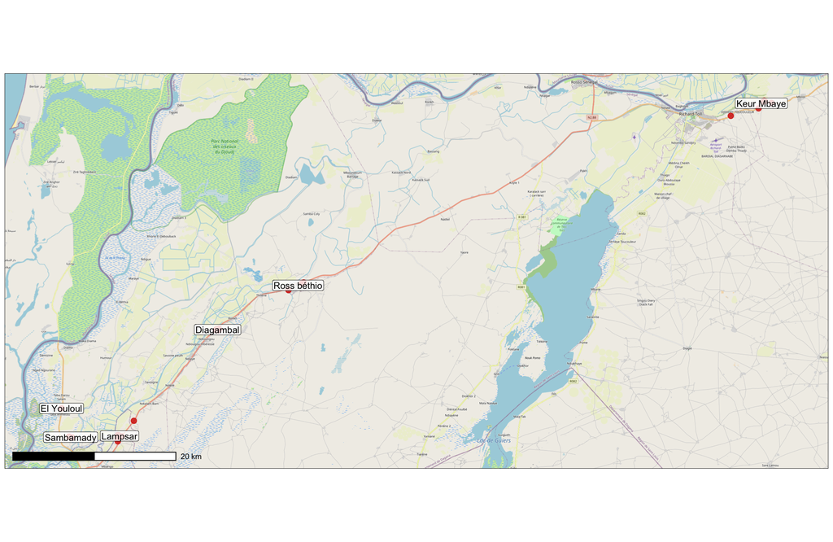

Figure 1: Saint-Louis region and the Senegal river delta. Red points show participants broad location.

Data Collection Dates

| indicator | value |
| --- | --- |
| First interview date | 23 April 2026 |
| Last interview date | 28 April 2026 |
| Survey days | 6 |

Table 1: Data collection dates. The table reports the first and last interview dates and the number of distinct survey days.

The sample includes 46 households across 6 villages.

Context

| section | indicator | unit | n | value |
| --- | --- | --- | --- | --- |
| Sample | Households interviewed | Households | 46 | 46.00 |
| Sample | Villages covered | Villages | 6 | 6.00 |
| Demographics | Mean household size | Household members | 46 | 9.67 |
| Demographics | Female-headed households (%) | Percent of households | 46 | 6.52 |
| Agriculture | Plots in roster | Plots | 123 | 123.00 |
| Agriculture | Plots with valid GPS area (%) | Percent of plots | 123 | 98.37 |
| Agriculture | Households with all plots mapped (%) | Percent of households with plots | 46 | 95.65 |
| Agriculture | Median GPS cultivated area among fully mapped households (m2) | m2 | 44 | 10320.59 |
| Recent seasons | Rice among cropped plot-seasons (%) | Percent of cropped plot-seasons | 214 | 74.30 |
| Production | Harvested plot-seasons | Plot-seasons | 113 | 113.00 |
| Production | Median harvest among harvested plot-seasons (kg) | kg | 113 | 2000.00 |
| Input-cost efficiency | Median input cost per kg harvested | Input cost per kg | 111 | 24.01 |
| Living standards | Households able to access emergency funds (%) | Percent of households | 46 | 15.22 |
| Food security | Mean rCSI score | Score | 46 | 3.17 |
| Health / exposure | Households with any member reporting open-water contact (%) | Percent of households | 46 | 100.00 |

Table 2: Context. The table summarizes the sample size and key baseline indicators.

# Household Labor and Demographics

This section describes household composition. Children are defined as members under 18; adults are members aged 18 or older. Working-age members are aged 18-64.

The first table summarizes the household-level demographic structure. It is meant to answer three basic baseline questions: how large households are, how many dependents and working-age members they contain, and how much household labor is (potentially) available for work.

Household Composition and Labor Availability

| section | indicator | n | mean | median | min | max | yes_n | yes_pct |
| --- | --- | --- | --- | --- | --- | --- | --- | --- |
| Demographics | Household size | 46 | 9.67 | 8.50 | 3.0 | 19 | — | — |
| Household composition | Female household members | 46 | 4.65 | 4.00 | 1.0 | 11 | — | — |
| Household composition | Male household members | 46 | 5.02 | 4.00 | 1.0 | 12 | — | — |
| Household composition | Share female household members (%) | 46 | 48.81 | 50.00 | 16.7 | 75 | — | — |
| Demographics | Female-headed household | 46 | — | — | — | — | 3 | 6.5 |
| Demographics | Household head age | 46 | 57.46 | 60.00 | 19.0 | 86 | — | — |
| Household composition | Children under 5 | 46 | 0.63 | 0.00 | 0.0 | 2 | — | — |
| Household composition | Children 5-17 | 46 | 2.85 | 2.00 | 0.0 | 8 | — | — |
| Demographics | Children under 18 | 46 | 3.48 | 3.00 | 0.0 | 9 | — | — |
| Household composition | Youth 18-24 | 46 | 1.41 | 1.00 | 0.0 | 5 | — | — |
| Household composition | Adults 25-64 | 46 | 4.28 | 4.00 | 1.0 | 12 | — | — |
| Demographics | Working-age members 18-64 | 46 | 5.70 | 5.00 | 1.0 | 14 | — | — |
| Household composition | Elderly 65+ | 46 | 0.50 | 0.00 | 0.0 | 2 | — | — |
| Household composition | Dependency ratio | 46 | 0.97 | 0.60 | 0.0 | 10 | — | — |
| Household composition | Child dependency ratio | 46 | 0.85 | 0.58 | 0.0 | 8 | — | — |
| Household composition | High child burden: children >= working-age members | 46 | — | — | — | — | 15 | 32.6 |
| Household labor | Share of working-age members doing household work (%) | 46 | 57.57 | 60.00 | 0.0 | 100 | — | — |
| Household labor | Share of working-age members doing outside wage work (%) | 46 | 39.69 | 40.00 | 0.0 | 80 | — | — |
| Demographics | Any member did agricultural work in past 12 months | 46 | — | — | — | — | 44 | 95.7 |

Table 3: Household composition and labor availability. Children are members under 18; working-age members are aged 18-64.

The next figure shows the average characteristics of individuals. Splitting each indicator between children and adults helps separate household labor availability from schooling/dependency.

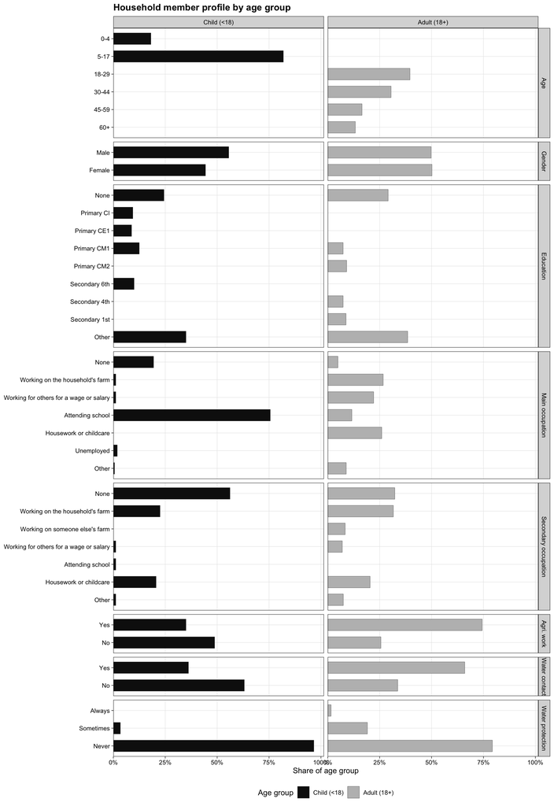

Figure 2: Household member profile by age group. Bars show the share of members within each child/adult group.

The labor-demographics figure focuses on the distribution of household size, dependency, working-age availability, and work shares (family business vs. outside salary).

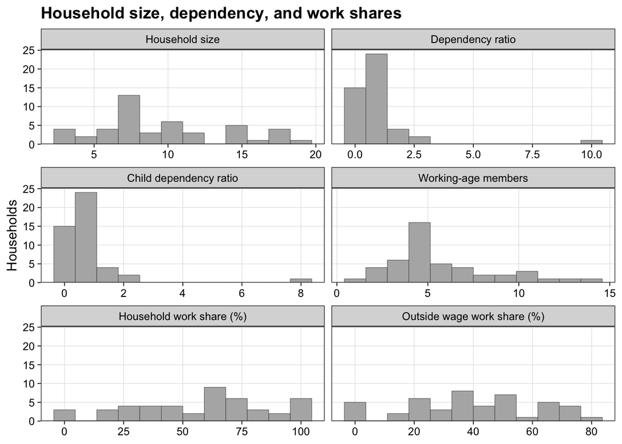

Figure 3: Household size, dependency, and work shares. Distributions are shown at the household level.

# Living Standards, Food, and Health

This section summarizes living standards, water and sanitation, financial access, rCSI (food insecurity), GAD-2 (anxiety), PHQ-2 (depression), health and water exposure.

## Living Standards

The living-standards tables summarize basic living standards, water and sanitation, energy use, and access to financial tools and community groups. The first table focuses on dwelling rooms, which is a key housing-density indicator. The second figure broadens the view to infrastructure, basic services, and financial access.

Dwelling Rooms

| indicator | n | mean | sd | median | min | max |
| --- | --- | --- | --- | --- | --- | --- |
| Separate rooms in household | 46 | 4.93 | 2.32 | 5 | 2 | 12 |

Table 4: Dwelling rooms. The table summarizes the number of separate rooms reported by households.

The next figure below expands the view to infrastructure, basic services, and financial access in overall sample distributions.

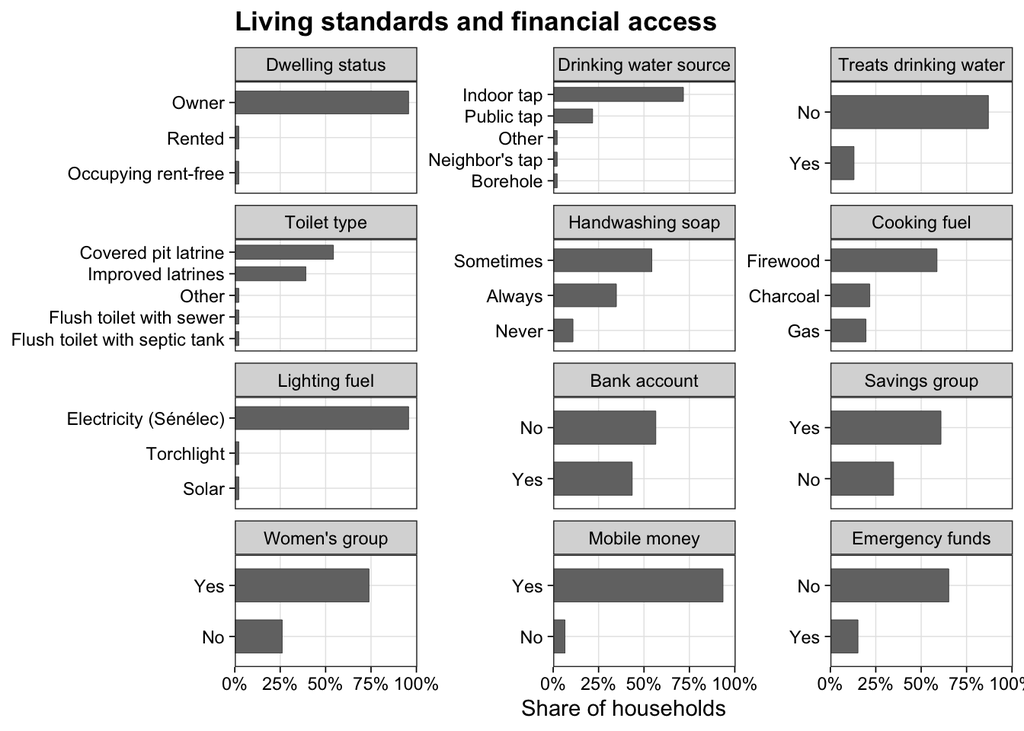

Figure 4: Living standards and financial access. Bars show the share of households in each category.

These household conditions provide context for the food security and mental health score distributions that follow.

## Livestock

Livestock ownership and sales provide additional context on household assets. The table is descriptive by species is a complement to the living-standards indicators.

Livestock Ownership and Sales by Species

| livestock_species_label | households | households_owning | pct_households_owning | mean_owned_among_owners | households_sold | pct_households_sold | mean_selling_price |
| --- | --- | --- | --- | --- | --- | --- | --- |
| animaux de trait | 46 | 7 | 15.2 | 1.14 | 1 | 2.2 | 50000 |
| bovins | 46 | 9 | 19.6 | 6.44 | 4 | 8.7 | 243750 |
| chevaux | 46 | 5 | 10.9 | 1.00 | 1 | 2.2 | 375000 |
| chèvres | 46 | 16 | 34.8 | 4.56 | 5 | 10.9 | 28333 |
| moutons | 46 | 17 | 37.0 | 3.35 | 4 | 8.7 | 61250 |
| porcs | 46 | 0 | 0.0 | — | 0 | 0.0 | — |
| volailles | 46 | 27 | 58.7 | 11.37 | 5 | 10.9 | 3400 |
| ânes | 46 | 7 | 15.2 | 1.14 | 0 | 0.0 | — |

Table 5: Livestock ownership and sales by species. The table reports ownership, sales, and recorded selling prices by species.

## Food Security and Mental Health

The score distributions show the spread of rCSI, GAD-2, and PHQ-2. rCSI is measured at the household level, while GAD-2 and PHQ-2 are answered by the farmer only. The correlation plot then displays whether food security, mental health, demographics, land, housing, and financial indicators move together in the sample.

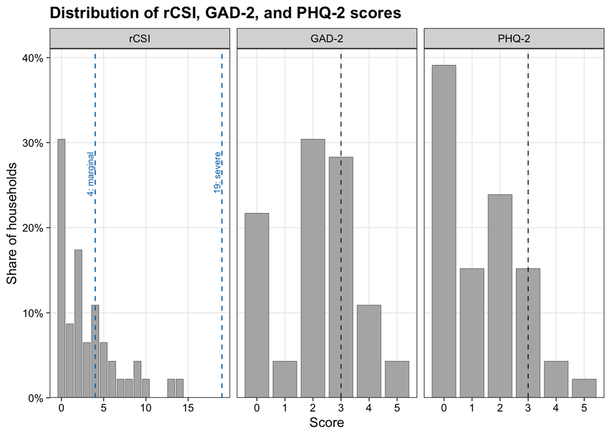

Figure 5: Distribution of rCSI, GAD-2, and PHQ-2 scores. Dashed lines mark concern cutoffs; for rCSI, 0-3 is minimal stress, 4-18 is marginal/stressed, and 19 or above is severe/crisis.

The following figure shows associations between the scores and household or household head measures.

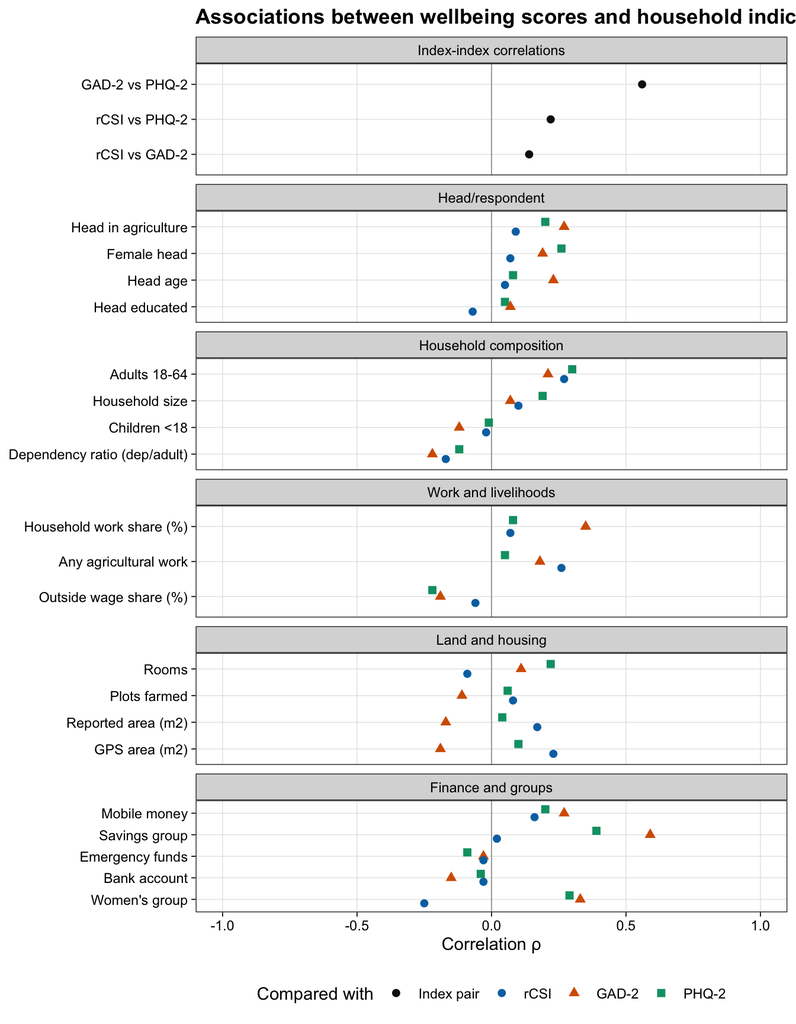

Figure 6: Associations between wellbeing scores and household indicators.

These associations can help identify patterns for further discussion on the relevance of food security and mental health indices for the experiment.

## Health and Water Exposure

The health table separates rice-field workers from non-rice-field workers. The survey did not ask these questions at the individual level (IRB protocol requirement on health information). The second table however shifts to the household roster and summarizes water contact by children and adults.

Health Indicators by Rice-Field Worker Status

| topic | rice_field_workers | n | yes_n | yes_pct |
| --- | --- | --- | --- | --- |
| Blood in urine | No | 46 | 14 | 30.4 |
| Blood in urine | Yes | 46 | 12 | 26.1 |
| Medical attention | No | 46 | 32 | 69.6 |
| Medical attention | Yes | 46 | 32 | 69.6 |
| Missed school/work due to illness | No | 46 | 11 | 23.9 |
| Missed school/work due to illness | Yes | 46 | 16 | 34.8 |
| Other illness | No | 46 | 29 | 63.0 |
| Other illness | Yes | 46 | 39 | 84.8 |
| Schistosomiasis diagnosis | No | 46 | 16 | 34.8 |
| Schistosomiasis diagnosis | Yes | 46 | 17 | 37.0 |
| Schistosomiasis treatment | No | 46 | 26 | 56.5 |
| Schistosomiasis treatment | Yes | 46 | 28 | 60.9 |

Table 6: Health indicators by rice-field worker status. The table reports household shares for each health indicator.

The household-level health indicators are complemented by individual-level information on whether members had water contact.

Open-Water Contact by Age Group

| group | label | n | pct |
| --- | --- | --- | --- |
| Adult (18+) | No | 96 | 33.8 |
| Adult (18+) | Yes | 188 | 66.2 |
| Child (<18) | No | 101 | 63.5 |
| Child (<18) | Yes | 58 | 36.5 |

Table 7: Water contact by age group. The table reports member-level shares by child/adult status.

The health figure shows the distribution of health indicators at the household level.

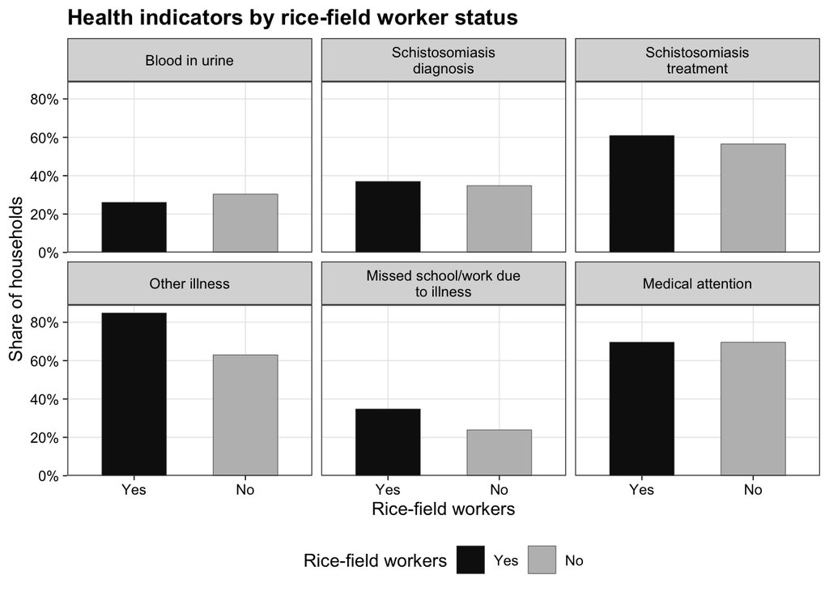

Figure 7: Health indicators by rice-field worker status. Bars show the share of households reporting each indicator.

# Land, Plot Measurement, and Crop Types

This section uses GPS-recorded coordinates (through ArcGIS Survey123) as the preferred plot area measure, over self reported ones. Comparative analysis of both measurement types aims to evaluate farmer land perception accuracy.

## Area Measurement

Household-level area comparisons are shown only for households with all plots mapped: a few plots could not be mapped due to the great distance from their respective households.

Mapping Completeness

| metric | value | pct |
| --- | --- | --- |
| plots in roster | 123 | — |
| plots with valid GPS area | 121 | 98.4 |
| households with plots | 46 | — |
| households with all plots mapped | 44 | 95.7 |

Table 8: Plot mapping completeness.

The figures below show examples of mapped plots.

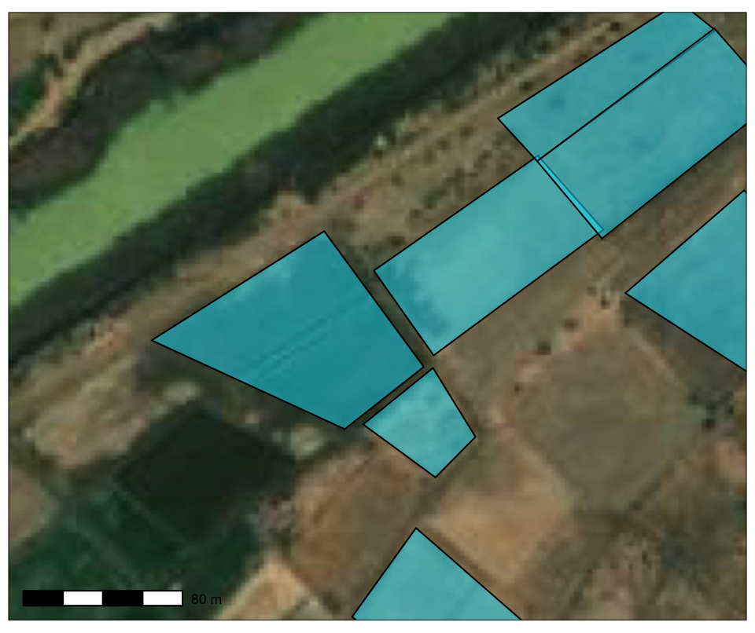

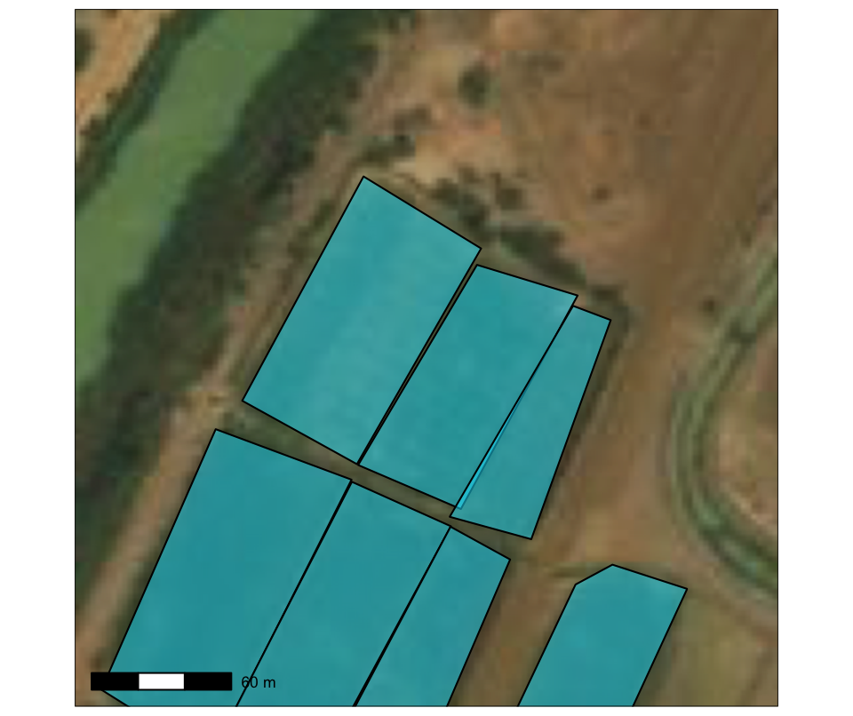

Figure 9: Mapped plot detail example 2.

Among mapped plots, the next table compares the reported plot area with the GPS-based area (polygon) used in the production summaries.

Mapped Plot Area Comparison

| variable | n | mean | sd | median | min | max |
| --- | --- | --- | --- | --- | --- | --- |
| plot_area_reported_m2 | 121 | 5333.47 | 3599.31 | 4400.00 | 950.00 | 20000.00 |
| plot_area_polygon_m2 | 121 | 5058.21 | 3497.21 | 4363.47 | 1025.96 | 25135.76 |
| plot_area_diff_m2 | 121 | 275.26 | 2179.81 | 66.91 | -5830.76 | 11182.54 |
| plot_area_abs_diff_m2 | 121 | 1268.60 | 1790.32 | 553.90 | 9.53 | 11182.54 |
| plot_area_pct_diff | 121 | 15.45 | 55.92 | 2.02 | -80.00 | 303.64 |
| plot_area_reported_to_polygon_ratio | 121 | 1.15 | 0.56 | 1.02 | 0.20 | 4.04 |

Table 9: Mapped plot area comparison. Reported plot area is compared with GPS-measured plot area among mapped plots.

The difference categories display the same comparison with bins that show the direction and size of reporting gaps.

Plot-Level Area Difference Categories

| area_difference_category | plots | pct_plots |
| --- | --- | --- |
| No valid GPS area | 2 | 1.6 |
| Reported 10-50% larger than GPS area | 27 | 22.0 |
| Reported 10-50% smaller than GPS area | 27 | 22.0 |
| Reported >50% larger than GPS area | 15 | 12.2 |
| Reported >50% smaller than GPS area | 5 | 4.1 |
| Reported within +/-10% of GPS area | 47 | 38.2 |

Table 10: Plot-level area difference categories. Categories summarize the magnitude and direction of reported area relative to GPS-based area.

Household-level comparisons are shown only for fully mapped households so that missing plot polygons do not biais total cultivated area.

Household-Level Area Comparison Among Fully Mapped Households

| variable | n | mean | sd | median | min | max |
| --- | --- | --- | --- | --- | --- | --- |
| household_reported_total_area_m2 | 44 | 16388.64 | 13539.71 | 9750.00 | 2500.00 | 70000.00 |
| sum_reported_plot_area_m2 | 44 | 14007.95 | 9636.10 | 9250.00 | 2500.00 | 35500.00 |
| sum_gps_plot_area_m2 | 44 | 13253.04 | 9664.19 | 10320.59 | 1542.45 | 38658.65 |
| household_reported_vs_sum_reported_diff_m2 | 44 | 2380.68 | 6729.31 | 0.00 | -5000.00 | 37500.00 |
| household_reported_vs_polygon_diff_m2 | 44 | 3135.60 | 6450.39 | 1114.58 | -4627.73 | 32143.41 |
| sum_reported_vs_polygon_diff_m2 | 44 | 754.92 | 3528.04 | 325.05 | -6263.34 | 12701.44 |
| household_reported_to_polygon_ratio | 44 | 1.24 | 0.35 | 1.11 | 0.63 | 1.97 |
| sum_reported_to_polygon_ratio | 44 | 1.13 | 0.31 | 1.04 | 0.55 | 1.94 |

Table 11: Household-level area comparison. The table is only households with all plots mapped.

The area-ratio figure shows whether reported areas tend to align with GPS areas. Values above one mean the reported area is larger than the GPS area and values below one mean the reported area is smaller.

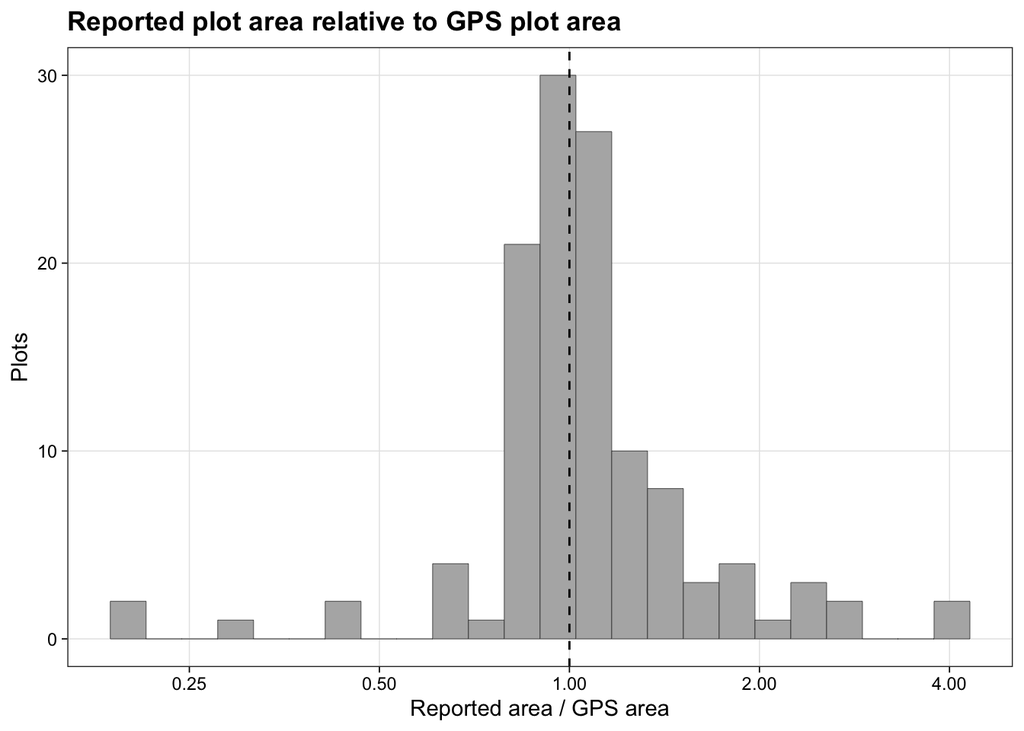

Figure 10: Reported plot area relative to GPS plot area. The dashed line marks equality between reported and GPS-based area.

## Plot Characteristics and Crop Types

The tables describe the land characteristics and crop types and harvest over the three last season recorded through the survey. Numeric plot characteristics summarize the context, while recent-season tables show how plot-seasons are distributed across crops and seasons.

The season are defined as: *Saison des pluies* (rainy season) = July-October; *Saison sèche fraîche* (cold-dry season) = November-February; and *Saison sèche chaude* (hot-dry season) = March-June.

Plot-Level Numeric Characteristics

| variable | n | mean | sd | median | min | max |
| --- | --- | --- | --- | --- | --- | --- |
| plot_area_gps_m2 | 121 | 5058.21 | 3497.21 | 4363.47 | 1025.96 | 25135.76 |
| plot_distance_from_home | 123 | 37.93 | 93.59 | 20.00 | 1.00 | 1000.00 |
| plot_farmed_years | 123 | 23.17 | 14.77 | 20.00 | 0.00 | 49.00 |
| rent_annual | 11 | 221363.64 | 293513.98 | 100000.00 | 30000.00 | 850000.00 |
| harvest_expected | 107 | 3279.37 | 4034.05 | 2500.00 | 0.00 | 35000.00 |
| fish_tilapia_count | 7 | 404.71 | 267.82 | 600.00 | 3.00 | 630.00 |
| fish_heterotis_count | 1 | 3.00 | — | 3.00 | 3.00 | 3.00 |
| fish_catfish_count | 2 | 765.00 | 190.92 | 765.00 | 630.00 | 900.00 |
| labor_total_count | 108 | 4.21 | 3.06 | 3.50 | 0.00 | 17.00 |

Table 12: Plot characteristics. Area measures are in square meters. Fish counts are conditional on having fish in the plot.

The recent-season table highlights plot-season outcomes over recall-period of agricultural activity.

Recent-Season Overview

| season_index | season_year | season_name | plot_seasons | cropped_plot_seasons | mean_harvest_kg | median_harvest_kg | mean_total_workers | median_total_workers |
| --- | --- | --- | --- | --- | --- | --- | --- | --- |
| 1 | 2026 | Saison sèche chaude (actuelle) | 123 | 108 | 863.75 | 617.5 | 4.00 | 4 |
| 2 | 2025 | Saison sèche fraîche | 115 | 43 | 5399.05 | 2887.5 | 6.30 | 5 |
| 3 | 2025 | Saison des pluies | 115 | 63 | 6717.14 | 1700.0 | 5.13 | 5 |

Table 13: Recent-season overview. Rows summarize plot-season records by season.

The crop-composition figure shows crop types mix. It shows the overall crop focus and the season-specific focus.

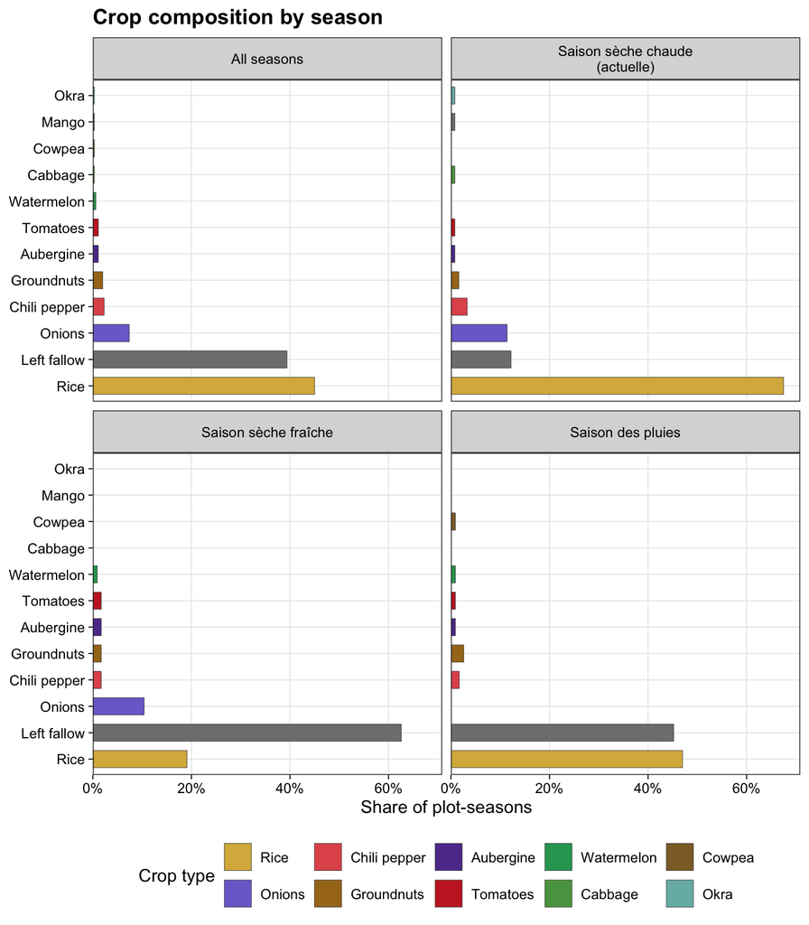

Figure 11: Crop composition by season. Bars show the share of plots growing each crop type.

# Inputs, Labor, and Harvest Outcomes

This section summarizes input intensity, labor intensity, harvest output, and productivity among harvested plot-seasons. Productivity measures are descriptive and do not account for output prices or non-observed costs. Only harvested plots are included.

## Overall Intensity and Productivity

This table shows five main indicators: input intensity, labor intensity, output per area, input cost per kilogram harvested, and kilograms harvested per unit of input cost.

Key Harvested Plot-Season Metrics

| metric | n | mean | median | min | max |
| --- | --- | --- | --- | --- | --- |
| Input cost / 1'000 m2 | 110 | 28894.84 | 13637.50 | 0.00 | 732979.35 |
| Workers / 1'000 m2 | 111 | 1.47 | 1.08 | 0.11 | 6.20 |
| Harvest kg / 1'000 m2 | 111 | 1724.13 | 453.35 | 0.00 | 67100.11 |
| Input cost / kg harvested | 111 | 86.49 | 24.01 | 0.00 | 2036.72 |
| Harvest kg / 1'000 input cost | 102 | 223.53 | 37.26 | 0.00 | 10714.29 |

Table 14: Indicators summarize input intensity, labor intensity, output, and rough input productivity among harvested plots.

## Seasonal Patterns

The season-level table shows whether input use, labor use, output, and rough input productivity differ across recent seasons.

Season-Level Intensity and Productivity

| Season | Harvested plot-seasons | Mean input cost / 1'000 m2 | Mean workers / 1'000 m2 | Mean harvest kg / 1'000 m2 | Mean input cost / kg harvested | Mean harvest kg / 1'000 input cost |
| --- | --- | --- | --- | --- | --- | --- |
| Saison sèche chaude (actuelle) | 8 | 29247.60 | 2.09 | 428.64 | 171.53 | 15.43 |
| Saison sèche fraîche | 42 | 40988.14 | 1.39 | 901.78 | 97.20 | 44.19 |
| Saison des pluies | 63 | 20720.30 | 1.45 | 2435.10 | 67.96 | 400.39 |

Table 15: Season-level intensity and productivity. Values are seasonal means among harvested plots.

## Crop-Level Patterns

The crop-level table pools harvested plots by crop to show which crops appear most often and how their average intensity and output compare.

Crop-Level Intensity and Productivity

| Crop | Harvested plot-seasons | Mean input cost / 1'000 m2 | Mean workers / 1'000 m2 | Mean harvest kg / 1'000 m2 | Mean input cost / kg harvested | Mean harvest kg / 1'000 input cost |
| --- | --- | --- | --- | --- | --- | --- |
| Rice | 75 | 27993.26 | 1.29 | 2112.51 | 74.86 | 335.20 |
| Onions | 12 | 40339.66 | 2.03 | 1557.27 | 32.90 | 54.78 |
| Chili pepper | 8 | 38249.48 | 2.09 | 671.03 | 124.88 | 20.45 |
| Groundnuts | 5 | 21187.11 | 2.61 | 305.84 | 113.17 | 32.21 |
| Aubergine | 4 | 36376.16 | 1.09 | 1599.70 | 154.83 | 19.01 |
| Tomatoes | 3 | 14509.15 | 0.60 | 100.83 | 295.97 | 5.20 |
| Watermelon | 2 | 2891.15 | 0.15 | 241.36 | 23.00 | 95.83 |
| Cabbage | 1 | 33098.50 | 4.04 | 2018.20 | 16.40 | 60.98 |
| Cowpea | 1 | 7265.52 | 4.04 | 72.66 | 100.00 | 10.00 |
| Mango | 1 | 29240.81 | 0.97 | 243.67 | 120.00 | 8.33 |
| Okra | 1 | 25094.17 | 1.08 | 64.99 | 386.11 | 2.59 |

Table 16: Crop-level intensity and productivity. Values are crop means across harvested plot-seasons.

Same production logic with average input cost per 1’000 m2 on the horizontal axis and average output per 1’000 m2 on the vertical axis. Each point is a crop type.

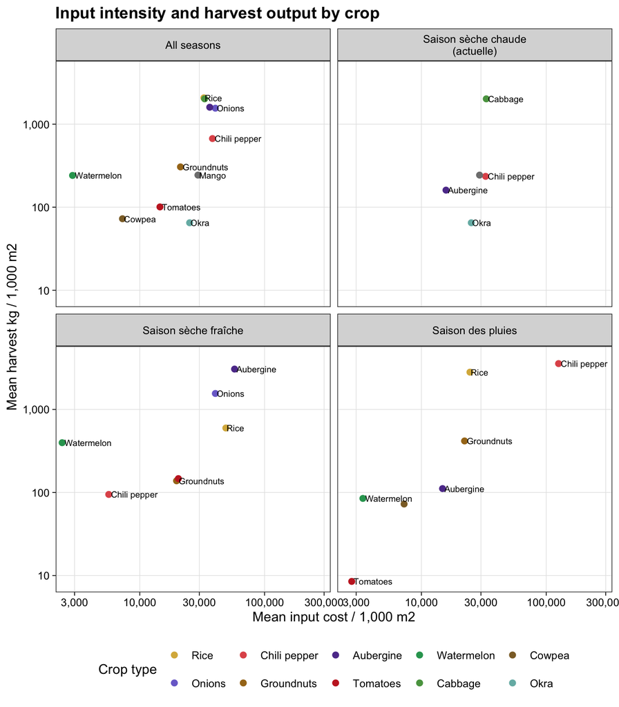

Figure 12: Input intensity and harvest output by crop.

The appendix provides additional descriptive tables for readers who want to browse the underlying summary statistics in more detail.

# Appendix

Household Labor and Dependency

| panel | indicator | n | mean | sd | median | min | max | yes_n | yes_pct |
| --- | --- | --- | --- | --- | --- | --- | --- | --- | --- |
| dependency_ratio_distribution | Dependency ratio: children <18 and elderly 65+ per working-age member 18-64 | 46 | 0.97 | 1.49 | 0.60 | 0 | 10 | — | — |
| child_dependency_ratio_distribution | Child dependency ratio: children <18 per working-age member 18-64 | 46 | 0.85 | 1.23 | 0.58 | 0 | 8 | — | — |
| high_child_burden | High child burden: children <18 >= working-age members 18-64 | 46 | — | — | — | — | — | 15 | 32.6 |
| working_age_labor_availability | Working-age members 18-64 | 46 | 5.70 | 3.02 | 5.00 | 1 | 14 | — | — |
| working_age_labor_availability | No working-age member 18-64 | 46 | — | — | — | — | — | 0 | 0.0 |
| working_age_labor_availability | At least two working-age members 18-64 | 46 | — | — | — | — | — | 45 | 97.8 |
| working_age_labor_availability | Any member did agricultural work in past 12 months | 46 | — | — | — | — | — | 44 | 95.7 |
| work_share_summary | Working-age household work share (%) | 46 | 57.57 | 28.35 | 60.00 | 0 | 100 | — | — |
| work_share_summary | Working-age outside wage work share (%) | 46 | 39.69 | 22.37 | 40.00 | 0 | 80 | — | — |

Table 17: Appendix household labor and dependency indicators. The table reports additional household-level labor availability and dependency summaries.

Member Age by Child/Adult Status

| group | variable | n | mean | sd | median | min | max |
| --- | --- | --- | --- | --- | --- | --- | --- |
| Child (<18) | member_age | 160 | 10.03 | 4.68 | 11 | 1 | 17 |
| Adult (18+) | member_age | 285 | 37.57 | 15.92 | 34 | 18 | 87 |

Table 18: Appendix member age. The table reports member age summaries by child/adult status.

Member Gender by Child/Adult Status

| group | value | label | n | variable | pct |
| --- | --- | --- | --- | --- | --- |
| Adult (18+) | 1 | Male | 142 | member_gender | 49.8 |
| Adult (18+) | 2 | Female | 143 | member_gender | 50.2 |
| Child (<18) | 1 | Male | 89 | member_gender | 55.6 |
| Child (<18) | 2 | Female | 71 | member_gender | 44.4 |

Table 19: Appendix member gender. The table reports gender distributions by child/adult status.

Member Education by Child/Adult Status

| group | value | label | n | variable | pct |
| --- | --- | --- | --- | --- | --- |
| Adult (18+) | -99 | Other | 19 | member_education | 6.7 |
| Adult (18+) | 0 | None | 83 | member_education | 29.1 |
| Adult (18+) | 1 | Primary CI | 9 | member_education | 3.2 |
| Adult (18+) | 10 | Secondary 3rd | 10 | member_education | 3.5 |
| Adult (18+) | 11 | Secondary 2nd | 7 | member_education | 2.5 |
| Adult (18+) | 12 | Secondary 1st | 25 | member_education | 8.8 |
| Adult (18+) | 13 | Secondary Final | 11 | member_education | 3.9 |
| Adult (18+) | 14 | Above secondary | 16 | member_education | 5.6 |
| Adult (18+) | 2 | Primary CP | 8 | member_education | 2.8 |
| Adult (18+) | 3 | Primary CE1 | 3 | member_education | 1.1 |
| Adult (18+) | 4 | Primary CE2 | 9 | member_education | 3.2 |
| Adult (18+) | 5 | Primary CM1 | 21 | member_education | 7.4 |
| Adult (18+) | 6 | Primary CM2 | 26 | member_education | 9.1 |
| Adult (18+) | 7 | Secondary 6th | 6 | member_education | 2.1 |
| Adult (18+) | 8 | Secondary 5th | 11 | member_education | 3.9 |
| Adult (18+) | 9 | Secondary 4th | 21 | member_education | 7.4 |
| Child (<18) | -99 | Other | 8 | member_education | 5.0 |
| Child (<18) | 0 | None | 39 | member_education | 24.4 |
| Child (<18) | 1 | Primary CI | 15 | member_education | 9.4 |
| Child (<18) | 10 | Secondary 3rd | 4 | member_education | 2.5 |
| Child (<18) | 11 | Secondary 2nd | 3 | member_education | 1.9 |
| Child (<18) | 12 | Secondary 1st | 1 | member_education | 0.6 |
| Child (<18) | 14 | Above secondary | 1 | member_education | 0.6 |
| Child (<18) | 2 | Primary CP | 9 | member_education | 5.6 |
| Child (<18) | 3 | Primary CE1 | 14 | member_education | 8.8 |
| Child (<18) | 4 | Primary CE2 | 10 | member_education | 6.2 |
| Child (<18) | 5 | Primary CM1 | 20 | member_education | 12.5 |
| Child (<18) | 6 | Primary CM2 | 6 | member_education | 3.8 |
| Child (<18) | 7 | Secondary 6th | 16 | member_education | 10.0 |
| Child (<18) | 8 | Secondary 5th | 8 | member_education | 5.0 |
| Child (<18) | 9 | Secondary 4th | 6 | member_education | 3.8 |

Table 20: Appendix member education. The table reports education distributions by child/adult status.

Main Occupation by Child/Adult Status

| group | value | label | n | variable | pct |
| --- | --- | --- | --- | --- | --- |
| Adult (18+) | 0 | None | 14 | occupation_main | 4.9 |
| Adult (18+) | 1 | Working on the household's farm | 76 | occupation_main | 26.7 |
| Adult (18+) | 2 | Fishing | 3 | occupation_main | 1.1 |
| Adult (18+) | 3 | Working on someone else's farm | 5 | occupation_main | 1.8 |
| Adult (18+) | 4 | Working in a non-farm enterprise owned and operated by the household | 14 | occupation_main | 4.9 |
| Adult (18+) | 5 | Working for others for a wage or salary | 63 | occupation_main | 22.1 |
| Adult (18+) | 6 | Attending school | 33 | occupation_main | 11.6 |
| Adult (18+) | 7 | Housework or childcare | 74 | occupation_main | 26.0 |
| Adult (18+) | 8 | Unemployed | 3 | occupation_main | 1.1 |
| Child (<18) | 0 | None | 31 | occupation_main | 19.4 |
| Child (<18) | 1 | Working on the household's farm | 2 | occupation_main | 1.2 |
| Child (<18) | 5 | Working for others for a wage or salary | 2 | occupation_main | 1.2 |
| Child (<18) | 6 | Attending school | 121 | occupation_main | 75.6 |
| Child (<18) | 7 | Housework or childcare | 1 | occupation_main | 0.6 |
| Child (<18) | 8 | Unemployed | 3 | occupation_main | 1.9 |

Table 21: Appendix main occupation. The table reports main occupation distributions by child/adult status.

Secondary Occupation by Child/Adult Status

| group | value | label | n | variable | pct_of_group_records |
| --- | --- | --- | --- | --- | --- |
| Adult (18+) | 0 | None | 92 | occupation_secondary | 30.2 |
| Adult (18+) | 1 | Working on the household's farm | 90 | occupation_secondary | 29.5 |
| Adult (18+) | 2 | Fishing | 9 | occupation_secondary | 3.0 |
| Adult (18+) | 3 | Working on someone else's farm | 24 | occupation_secondary | 7.9 |
| Adult (18+) | 4 | Working in a non-farm enterprise owned and operated by the household | 5 | occupation_secondary | 1.6 |
| Adult (18+) | 5 | Working for others for a wage or salary | 20 | occupation_secondary | 6.6 |
| Adult (18+) | 6 | Attending school | 1 | occupation_secondary | 0.3 |
| Adult (18+) | 7 | Housework or childcare | 58 | occupation_secondary | 19.0 |
| Adult (18+) | 8 | Unemployed | 6 | occupation_secondary | 2.0 |
| Child (<18) | 0 | None | 90 | occupation_secondary | 54.5 |
| Child (<18) | 1 | Working on the household's farm | 36 | occupation_secondary | 21.8 |
| Child (<18) | 3 | Working on someone else's farm | 1 | occupation_secondary | 0.6 |
| Child (<18) | 5 | Working for others for a wage or salary | 2 | occupation_secondary | 1.2 |
| Child (<18) | 6 | Attending school | 2 | occupation_secondary | 1.2 |
| Child (<18) | 7 | Housework or childcare | 33 | occupation_secondary | 20.0 |
| Child (<18) | 8 | Unemployed | 1 | occupation_secondary | 0.6 |

Table 22: Appendix secondary occupation. The table reports secondary occupation distributions by child/adult status.

Agricultural Work by Child/Adult Status

| group | variable | n | yes_n | yes_pct |
| --- | --- | --- | --- | --- |
| Child (<18) | does_agriwork_12m | 134 | 56 | 41.8 |
| Adult (18+) | does_agriwork_12m | 285 | 212 | 74.4 |

Table 23: Appendix agricultural work. The table reports agricultural work in the past 12 months by child/adult status.

Water Contact by Child/Adult Status

| group | variable | n | yes_n | yes_pct |
| --- | --- | --- | --- | --- |
| Child (<18) | has_watercontact_12m | 159 | 58 | 36.5 |
| Adult (18+) | has_watercontact_12m | 284 | 188 | 66.2 |

Table 24: Appendix water contact. The table reports open-water contact in the past 12 months by child/adult status.

Water Protection Among Exposed Members

| group | value | label | n | variable | pct |
| --- | --- | --- | --- | --- | --- |
| Adult (18+) | 0 | Never | 149 | waterprotection_frequency | 79.3 |
| Adult (18+) | 1 | Sometimes | 36 | waterprotection_frequency | 19.1 |
| Adult (18+) | 2 | Always | 3 | waterprotection_frequency | 1.6 |
| Child (<18) | 0 | Never | 56 | waterprotection_frequency | 96.6 |
| Child (<18) | 1 | Sometimes | 2 | waterprotection_frequency | 3.4 |

Table 25: Appendix water protection. The table reports water protection frequency among exposed members by child/adult status.

Household Head Age

| indicator | n | mean | sd | median | min | max |
| --- | --- | --- | --- | --- | --- | --- |
| Household head age | 46 | 57.46 | 13.35 | 60 | 19 | 86 |

Table 26: Appendix household head age. The table summarizes age among household heads.

Household Head Gender

| variable | value | label | n | pct |
| --- | --- | --- | --- | --- |
| head_gender | 1 | Male | 43 | 93.5 |
| head_gender | 2 | Female | 3 | 6.5 |

Table 27: Appendix household head gender. The table reports the gender distribution of household heads.

Household Head Education

| variable | value | label | n | pct |
| --- | --- | --- | --- | --- |
| head_education | -99 | Other | 10 | 21.7 |
| head_education | 0 | None | 18 | 39.1 |
| head_education | 12 | Secondary 1st | 2 | 4.3 |
| head_education | 14 | Above secondary | 3 | 6.5 |
| head_education | 3 | Primary CE1 | 1 | 2.2 |
| head_education | 4 | Primary CE2 | 1 | 2.2 |
| head_education | 6 | Primary CM2 | 9 | 19.6 |
| head_education | 7 | Secondary 6th | 1 | 2.2 |
| head_education | 9 | Secondary 4th | 1 | 2.2 |

Table 28: Appendix household head education. The table reports education levels among household heads.

Household Head Occupation

| variable | value | label | n | pct |
| --- | --- | --- | --- | --- |
| head_occupation | 0 | None | 1 | 2.2 |
| head_occupation | 1 | Working on the household's farm | 38 | 82.6 |
| head_occupation | 4 | Working in a non-farm enterprise owned and operated by the household | 1 | 2.2 |
| head_occupation | 5 | Working for others for a wage or salary | 5 | 10.9 |
| head_occupation | 7 | Housework or childcare | 1 | 2.2 |

Table 29: Appendix household head occupation. The table reports main occupation among household heads.

Water, Sanitation, and Energy

| label | variable | pct | value | n |
| --- | --- | --- | --- | --- |
| Owner | dwelling_status | 95.7 | 1 | 44 |
| Rented | dwelling_status | 2.2 | 2 | 1 |
| Occupying rent-free | dwelling_status | 2.2 | 3 | 1 |
| Indoor tap | drinking_water_source | 71.7 | 1 | 33 |
| Public tap | drinking_water_source | 21.7 | 2 | 10 |
| Neighbor's tap | drinking_water_source | 2.2 | 3 | 1 |
| Protected well | drinking_water_source | 2.2 | 4 | 1 |
| Borehole | drinking_water_source | 2.2 | 6 | 1 |
| No | is_water_treated | 87.0 | 0 | 40 |
| Yes | is_water_treated | 13.0 | 1 | 6 |
| Never | handwashing_soap_frequency | 10.9 | 0 | 5 |
| Sometimes | handwashing_soap_frequency | 54.3 | 1 | 25 |
| Always | handwashing_soap_frequency | 34.8 | 2 | 16 |
| Charcoal | cooking_fuel | 21.7 | 1 | 10 |
| Firewood | cooking_fuel | 58.7 | 2 | 27 |
| Gas | cooking_fuel | 19.6 | 3 | 9 |
| Electricity (Sénélec) | lighting_fuel | 95.7 | 1 | 44 |
| Solar | lighting_fuel | 2.2 | 3 | 1 |
| Torchlight | lighting_fuel | 2.2 | 7 | 1 |

Table 30: Appendix water, sanitation, and energy. The table reports categorical living-standard indicators.

Water Treatment Methods Among Treaters

| variable | value | label | n | pct_of_records |
| --- | --- | --- | --- | --- |
| water_treatment_method | 1 | Bleach / Aqua tabs | 5 | 83.3 |
| water_treatment_method | 3 | Filtration | 1 | 16.7 |

Table 31: Appendix water treatment methods. The table reports water treatment methods among households that treat drinking water.

Financial Access and Groups

| label | variable | pct | value | n |
| --- | --- | --- | --- | --- |
| No | has_bank_account | 56.5 | 0 | 26 |
| Yes | has_bank_account | 43.5 | 1 | 20 |
| Don't know | has_savings_group | 4.3 | -98 | 2 |
| No | has_savings_group | 34.8 | 0 | 16 |
| Yes | has_savings_group | 60.9 | 1 | 28 |
| No | has_womens_group | 26.1 | 0 | 12 |
| Yes | has_womens_group | 73.9 | 1 | 34 |
| No | has_mobile_money | 6.5 | 0 | 3 |
| Yes | has_mobile_money | 93.5 | 1 | 43 |
| Don't know | has_emergency_fund_access | 19.6 | -98 | 9 |
| No | has_emergency_fund_access | 65.2 | 0 | 30 |
| Yes | has_emergency_fund_access | 15.2 | 1 | 7 |

Table 32: Appendix financial access. The table reports accounts, groups, mobile money, and emergency-fund access.

Emergency Funds Sources

| variable | value | label | n | pct_of_records |
| --- | --- | --- | --- | --- |
| emergency_funds_source | 2 | Borrow from village savings/loan account | 1 | 14.3 |
| emergency_funds_source | 3 | Borrow from neighbors/friends/relatives | 4 | 57.1 |
| emergency_funds_source | 4 | Use own savings | 3 | 42.9 |
| emergency_funds_source | 5 | Sell crops or livestock | 1 | 14.3 |
| emergency_funds_source | 6 | Sell other property or belongings | 1 | 14.3 |

Table 33: Appendix emergency funds sources. The table reports sources among households with access to emergency funds.

Food Security and Mental Health Score Distributions

| index | score | households | pct_households |
| --- | --- | --- | --- |
| GAD-2 | 0 | 10 | 21.7 |
| GAD-2 | 1 | 2 | 4.3 |
| GAD-2 | 2 | 14 | 30.4 |
| GAD-2 | 3 | 13 | 28.3 |
| GAD-2 | 4 | 5 | 10.9 |
| GAD-2 | 5 | 2 | 4.3 |
| PHQ-2 | 0 | 18 | 39.1 |
| PHQ-2 | 1 | 7 | 15.2 |
| PHQ-2 | 2 | 11 | 23.9 |
| PHQ-2 | 3 | 7 | 15.2 |
| PHQ-2 | 4 | 2 | 4.3 |
| PHQ-2 | 5 | 1 | 2.2 |
| rCSI | 0 | 14 | 30.4 |
| rCSI | 1 | 4 | 8.7 |
| rCSI | 2 | 8 | 17.4 |
| rCSI | 3 | 3 | 6.5 |
| rCSI | 4 | 5 | 10.9 |
| rCSI | 5 | 3 | 6.5 |
| rCSI | 6 | 2 | 4.3 |
| rCSI | 7 | 1 | 2.2 |
| rCSI | 8 | 1 | 2.2 |
| rCSI | 9 | 2 | 4.3 |
| rCSI | 10 | 1 | 2.2 |
| rCSI | 13 | 1 | 2.2 |
| rCSI | 14 | 1 | 2.2 |

Table 34: Appendix score distributions. The table reports rCSI, GAD-2, and PHQ-2 score frequencies.

Food Security and Mental Health Score Thresholds

| index | threshold | n | households_above_threshold | pct_above_threshold |
| --- | --- | --- | --- | --- |
| GAD-2 | Screening cutoff >=3 | 46 | 20 | 43.5 |
| PHQ-2 | Screening cutoff >=3 | 46 | 10 | 21.7 |
| rCSI | Any coping behavior | 46 | 32 | 69.6 |

Table 35: Appendix score thresholds. The table reports shares above selected rCSI, GAD-2, and PHQ-2 thresholds.

Pairwise Index Correlations

| index_1 | index_2 | n | spearman_rho |
| --- | --- | --- | --- |
| rCSI | GAD-2 | 46 | 0.14 |
| rCSI | PHQ-2 | 46 | 0.22 |
| GAD-2 | PHQ-2 | 46 | 0.56 |

Table 36: Appendix index correlations. The table reports pairwise Spearman correlations among rCSI, GAD-2, and PHQ-2.

Living-Standard Associations with Wellbeing Scores

| living_standard | index | n | spearman_rho | panel |
| --- | --- | --- | --- | --- |
| Reported area (m2) | GAD-2 | 44 | -0.17 | — |
| Reported area (m2) | PHQ-2 | 44 | 0.04 | — |
| Reported area (m2) | rCSI | 44 | 0.17 | — |
| GPS area (m2) | GAD-2 | 44 | -0.19 | — |
| GPS area (m2) | PHQ-2 | 44 | 0.10 | — |
| GPS area (m2) | rCSI | 44 | 0.23 | — |
| Bank account | GAD-2 | 46 | -0.15 | Finance and groups |
| Bank account | PHQ-2 | 46 | -0.04 | Finance and groups |
| Bank account | rCSI | 46 | -0.03 | Finance and groups |
| Emergency funds | GAD-2 | 46 | -0.03 | Finance and groups |
| Emergency funds | PHQ-2 | 46 | -0.09 | Finance and groups |
| Emergency funds | rCSI | 46 | -0.03 | Finance and groups |
| Mobile money | GAD-2 | 46 | 0.27 | Finance and groups |
| Mobile money | PHQ-2 | 46 | 0.20 | Finance and groups |
| Mobile money | rCSI | 46 | 0.16 | Finance and groups |
| Savings group | GAD-2 | 46 | 0.59 | Finance and groups |
| Savings group | PHQ-2 | 46 | 0.39 | Finance and groups |
| Savings group | rCSI | 46 | 0.02 | Finance and groups |
| Women's group | GAD-2 | 46 | 0.33 | Finance and groups |
| Women's group | PHQ-2 | 46 | 0.29 | Finance and groups |
| Women's group | rCSI | 46 | -0.25 | Finance and groups |

Table 37: Appendix living-standard associations. The table reports Spearman correlations between selected living-standard indicators and wellbeing scores.

Food Security Scores

| variable | n | mean | sd | median | min | max |
| --- | --- | --- | --- | --- | --- | --- |
| rcsi_1 | 46 | 1.02 | 1.48 | 0.0 | 0 | 7 |
| rcsi_2 | 46 | 1.33 | 1.79 | 0.5 | 0 | 7 |
| rcsi_3 | 46 | 0.35 | 0.85 | 0.0 | 0 | 4 |
| rcsi_4 | 46 | 0.30 | 0.89 | 0.0 | 0 | 4 |
| rcsi_5 | 46 | 0.17 | 1.04 | 0.0 | 0 | 7 |
| rcsi_total | 46 | 3.17 | 3.55 | 2.0 | 0 | 14 |

Table 38: Appendix food security scores. The table reports rCSI item and total-score summaries.

Food Security Asset Sales

| label | variable | pct_of_records | value | n |
| --- | --- | --- | --- | --- |
| Other | rcsi_assets_sold | 4.3 | -99 | 2 |
| None | rcsi_assets_sold | 71.7 | 0 | 33 |
| Livestock | rcsi_assets_sold | 21.7 | 1 | 10 |
| Production tools | rcsi_assets_sold | 2.2 | 3 | 1 |
| Drawing from other resources | rcsi_assets_sold | 2.2 | 5 | 1 |

Table 39: Appendix food security asset sales. The table reports asset-sale categories used in the food security module.

Mental Health Scores

| variable | n | mean | sd | median | min | max |
| --- | --- | --- | --- | --- | --- | --- |
| gad2_total | 46 | 2.15 | 1.43 | 2 | 0 | 5 |
| phq2_total | 46 | 1.37 | 1.37 | 1 | 0 | 5 |

Table 40: Appendix mental health scores. The table reports GAD-2 and PHQ-2 score summaries.

GAD-2 Items

| label | variable | pct | value | n |
| --- | --- | --- | --- | --- |
| Not at all | gad2_1 | 26.1 | 0 | 12 |
| Several days | gad2_1 | 30.4 | 1 | 14 |
| More than half of the days | gad2_1 | 41.3 | 2 | 19 |
| Nearly every day | gad2_1 | 2.2 | 3 | 1 |
| Not at all | gad2_2 | 32.6 | 0 | 15 |
| Several days | gad2_2 | 43.5 | 1 | 20 |
| More than half of the days | gad2_2 | 19.6 | 2 | 9 |
| Nearly every day | gad2_2 | 4.3 | 3 | 2 |

Table 41: Appendix GAD-2 items. The table reports categorical responses to GAD-2 items.

PHQ-2 Items

| label | variable | pct | value | n |
| --- | --- | --- | --- | --- |
| Not at all | phq2_1 | 47.8 | 0 | 22 |
| Several days | phq2_1 | 34.8 | 1 | 16 |
| More than half of the days | phq2_1 | 15.2 | 2 | 7 |
| Nearly every day | phq2_1 | 2.2 | 3 | 1 |
| Not at all | phq2_2 | 54.3 | 0 | 25 |
| Several days | phq2_2 | 28.3 | 1 | 13 |
| More than half of the days | phq2_2 | 15.2 | 2 | 7 |
| Nearly every day | phq2_2 | 2.2 | 3 | 1 |

Table 42: Appendix PHQ-2 items. The table reports categorical responses to PHQ-2 items.

Water-Contact Locations Among Exposed Members

| variable | value | label | n | pct_of_records |
| --- | --- | --- | --- | --- |
| watercontact_location | 1 | Canals | 245 | 99.6 |
| watercontact_location | 2 | Rivers | 27 | 11.0 |
| watercontact_location | 3 | Flooded fields | 47 | 19.1 |

Table 43: Appendix water-contact locations. The table reports locations among members with open-water contact.

Water-Contact Reasons Among Exposed Members

| variable | value | label | n | pct_of_records |
| --- | --- | --- | --- | --- |
| watercontact_reason | 1 | Agricultural work | 171 | 69.5 |
| watercontact_reason | 2 | Fishing | 4 | 1.6 |
| watercontact_reason | 3 | Wash clothes | 75 | 30.5 |
| watercontact_reason | 4 | Do the dishes | 52 | 21.1 |
| watercontact_reason | 5 | Harvest aquatic vegetation | 25 | 10.2 |
| watercontact_reason | 6 | Swim/Bathe | 123 | 50.0 |
| watercontact_reason | 7 | Play | 29 | 11.8 |
| watercontact_reason | 8 | Cross | 25 | 10.2 |
| watercontact_reason | 9 | Care for livestock | 7 | 2.8 |

Table 44: Appendix water-contact reasons. The table reports reasons among members with open-water contact.

Water Protection Among Exposed Members

| variable | value | label | n | pct |
| --- | --- | --- | --- | --- |
| waterprotection_frequency | 0 | Never | 205 | 83.3 |
| waterprotection_frequency | 1 | Sometimes | 38 | 15.4 |
| waterprotection_frequency | 2 | Always | 3 | 1.2 |

Table 45: Appendix water protection. The table reports water protection frequency among exposed members.

Illness-Related Days Missed

| variable | n | mean | sd | median | min | max |
| --- | --- | --- | --- | --- | --- | --- |
| hh_school_missed_ricefield | 16 | 1.12 | 2.42 | 0.0 | 0 | 9 |
| hh_work_missed_ricefield | 16 | 9.56 | 8.00 | 7.5 | 0 | 30 |
| hh_school_missed_noricefield | 11 | 6.82 | 8.98 | 1.0 | 0 | 20 |
| hh_work_missed_noricefield | 11 | 4.27 | 4.03 | 3.0 | 0 | 10 |

Table 46: Appendix illness-related days missed. The table summarizes school and work days missed.

Household Mapping Completeness

| household_id | plots_roster | plots_with_reported_area | plots_mapped | all_plots_mapped | mapping_status |
| --- | --- | --- | --- | --- | --- |
| 101 | 6 | 6 | 5 | FALSE | At least one plot not mapped |
| 102 | 1 | 1 | 1 | TRUE | All plots mapped |
| 103 | 2 | 2 | 2 | TRUE | All plots mapped |
| 104 | 3 | 3 | 3 | TRUE | All plots mapped |
| 105 | 2 | 2 | 2 | TRUE | All plots mapped |
| 106 | 6 | 6 | 6 | TRUE | All plots mapped |
| 107 | 3 | 3 | 3 | TRUE | All plots mapped |
| 108 | 3 | 3 | 3 | TRUE | All plots mapped |
| 109 | 4 | 4 | 4 | TRUE | All plots mapped |
| 201 | 8 | 8 | 8 | TRUE | All plots mapped |
| 202 | 2 | 2 | 2 | TRUE | All plots mapped |
| 301 | 2 | 2 | 2 | TRUE | All plots mapped |
| 302 | 1 | 1 | 1 | TRUE | All plots mapped |
| 303 | 1 | 1 | 1 | TRUE | All plots mapped |
| 304 | 2 | 2 | 2 | TRUE | All plots mapped |
| 305 | 2 | 2 | 2 | TRUE | All plots mapped |
| 306 | 2 | 2 | 2 | TRUE | All plots mapped |
| 307 | 1 | 1 | 1 | TRUE | All plots mapped |
| 308 | 2 | 2 | 2 | TRUE | All plots mapped |
| 309 | 1 | 1 | 1 | TRUE | All plots mapped |
| 310 | 2 | 2 | 2 | TRUE | All plots mapped |
| 311 | 3 | 3 | 3 | TRUE | All plots mapped |
| 401 | 1 | 1 | 1 | TRUE | All plots mapped |
| 402 | 2 | 2 | 2 | TRUE | All plots mapped |
| 403 | 2 | 2 | 2 | TRUE | All plots mapped |
| 404 | 2 | 2 | 2 | TRUE | All plots mapped |
| 407 | 1 | 1 | 1 | TRUE | All plots mapped |
| 408 | 1 | 1 | 1 | TRUE | All plots mapped |
| 409 | 1 | 1 | 1 | TRUE | All plots mapped |
| 410 | 2 | 2 | 2 | TRUE | All plots mapped |
| 411 | 2 | 2 | 2 | TRUE | All plots mapped |
| 412 | 2 | 2 | 2 | TRUE | All plots mapped |
| 413 | 1 | 1 | 1 | TRUE | All plots mapped |
| 414 | 3 | 3 | 3 | TRUE | All plots mapped |
| 501 | 7 | 7 | 7 | TRUE | All plots mapped |
| 502 | 2 | 2 | 2 | TRUE | All plots mapped |
| 503 | 2 | 2 | 1 | FALSE | At least one plot not mapped |
| 601 | 3 | 3 | 3 | TRUE | All plots mapped |
| 602 | 6 | 6 | 6 | TRUE | All plots mapped |
| 603 | 2 | 2 | 2 | TRUE | All plots mapped |
| 604 | 5 | 5 | 5 | TRUE | All plots mapped |
| 605 | 4 | 4 | 4 | TRUE | All plots mapped |
| 606 | 4 | 4 | 4 | TRUE | All plots mapped |
| 607 | 5 | 5 | 5 | TRUE | All plots mapped |
| 608 | 3 | 3 | 3 | TRUE | All plots mapped |
| 609 | 1 | 1 | 1 | TRUE | All plots mapped |

Table 47: Appendix household mapping completeness. The table reports plot mapping status by household.

Household Area Difference Categories

| household_area_difference_category | households | pct_households |
| --- | --- | --- |
| Household total 10-50% larger than GPS total | 11 | 25.0 |
| Household total 10-50% smaller than GPS total | 1 | 2.3 |
| Household total >50% larger than GPS total | 11 | 25.0 |
| Household total within +/-10% of GPS total | 21 | 47.7 |

Table 48: Appendix household area difference categories. The table reports household-level area difference categories among fully mapped households.

Large Plot-Area Differences

| household_id | plot_id | plot_area_reported_m2 | plot_area_polygon_m2 | has_valid_gps_area | plot_area_diff_m2 | plot_area_abs_diff_m2 | plot_area_pct_diff | plot_area_reported_to_polygon_ratio | area_difference_category |
| --- | --- | --- | --- | --- | --- | --- | --- | --- | --- |
| 404 | 404F01 | 20000 | 8817.46 | TRUE | 11182.54 | 11182.54 | 126.82 | 2.27 | Reported >50% larger than GPS area |
| 108 | 108F01 | 15000 | 6705.18 | TRUE | 8294.82 | 8294.82 | 123.71 | 2.24 | Reported >50% larger than GPS area |
| 104 | 104F03 | 12000 | 4539.15 | TRUE | 7460.85 | 7460.85 | 164.37 | 2.64 | Reported >50% larger than GPS area |
| 109 | 109F02 | 5000 | 10830.76 | TRUE | -5830.76 | 5830.76 | -53.84 | 0.46 | Reported >50% smaller than GPS area |
| 411 | 411F02 | 4000 | 9219.69 | TRUE | -5219.69 | 5219.69 | -56.61 | 0.43 | Reported >50% smaller than GPS area |
| 107 | 107F02 | 1200 | 5999.75 | TRUE | -4799.75 | 4799.75 | -80.00 | 0.20 | Reported >50% smaller than GPS area |
| 104 | 104F02 | 8000 | 3268.93 | TRUE | 4731.07 | 4731.07 | 144.73 | 2.45 | Reported >50% larger than GPS area |
| 605 | 605F01 | 10000 | 6028.45 | TRUE | 3971.55 | 3971.55 | 65.88 | 1.66 | Reported >50% larger than GPS area |
| 412 | 412F02 | 5000 | 1238.73 | TRUE | 3761.27 | 3761.27 | 303.64 | 4.04 | Reported >50% larger than GPS area |
| 606 | 606F01 | 1000 | 4741.29 | TRUE | -3741.29 | 3741.29 | -78.91 | 0.21 | Reported >50% smaller than GPS area |
| 109 | 109F01 | 8600 | 5283.42 | TRUE | 3316.58 | 3316.58 | 62.77 | 1.63 | Reported >50% larger than GPS area |
| 609 | 609F01 | 7000 | 3887.88 | TRUE | 3112.12 | 3112.12 | 80.05 | 1.80 | Reported >50% larger than GPS area |
| 601 | 601F03 | 5000 | 1953.10 | TRUE | 3046.90 | 3046.90 | 156.00 | 2.56 | Reported >50% larger than GPS area |
| 414 | 414F03 | 4000 | 1025.96 | TRUE | 2974.04 | 2974.04 | 289.88 | 3.90 | Reported >50% larger than GPS area |
| 605 | 605F04 | 5000 | 2588.26 | TRUE | 2411.74 | 2411.74 | 93.18 | 1.93 | Reported >50% larger than GPS area |
| 107 | 107F01 | 950 | 3286.76 | TRUE | -2336.76 | 2336.76 | -71.10 | 0.29 | Reported >50% smaller than GPS area |
| 303 | 303F01 | 5000 | 2806.30 | TRUE | 2193.70 | 2193.70 | 78.17 | 1.78 | Reported >50% larger than GPS area |
| 307 | 307F01 | 5000 | 2953.17 | TRUE | 2046.83 | 2046.83 | 69.31 | 1.69 | Reported >50% larger than GPS area |
| 108 | 108F03 | 3000 | 1177.79 | TRUE | 1822.21 | 1822.21 | 154.71 | 2.55 | Reported >50% larger than GPS area |
| 102 | 102F01 | 3000 | 1542.45 | TRUE | 1457.55 | 1457.55 | 94.50 | 1.94 | Reported >50% larger than GPS area |

Table 49: Appendix large plot-area differences. The table lists mapped plots where reported and GPS area differ by more than 50 percent.

Plot Categorical Characteristics

| label | variable | pct | value | n |
| --- | --- | --- | --- | --- |
| Owned | tenure_system | 81.3 | 1 | 100 |
| Rented | tenure_system | 8.9 | 2 | 11 |
| Borrowed | tenure_system | 4.9 | 3 | 6 |
| Communal | tenure_system | 4.9 | 4 | 6 |
| No | has_property_title | 45.5 | 0 | 56 |
| Yes | has_property_title | 35.8 | 1 | 44 |
| Sand | soil_type | 11.4 | 1 | 14 |
| Clay | soil_type | 82.9 | 2 | 102 |
| Mainly mixture sand/clay | soil_type | 4.9 | 3 | 6 |
| Forest soil rich clayey loam | soil_type | 0.8 | 4 | 1 |
| Year round | is_irrigated | 29.3 | 1 | 36 |
| Seasonal | is_irrigated | 70.7 | 2 | 87 |
| No | is_water_filled | 21.1 | 0 | 26 |
| Yes | is_water_filled | 78.9 | 1 | 97 |
| No | plot_has_fish | 72.4 | 0 | 89 |
| Yes | plot_has_fish | 6.5 | 1 | 8 |
| Land preparation | crop_stage_today | 10.6 | 1 | 13 |
| Pre germination | crop_stage_today | 43.1 | 2 | 53 |
| Post germination pre-grain | crop_stage_today | 8.9 | 3 | 11 |
| Flowering/heading | crop_stage_today | 8.1 | 4 | 10 |
| Grain filling | crop_stage_today | 1.6 | 5 | 2 |
| Maturing/ripening | crop_stage_today | 7.3 | 6 | 9 |
| Ready to harvest | crop_stage_today | 5.7 | 7 | 7 |
| Harvesting ongoing | crop_stage_today | 1.6 | 8 | 2 |
| Already harvested | crop_stage_today | 0.8 | 9 | 1 |
| Sow | rice_planting_method | 53.7 | 1 | 66 |
| Transplant | rice_planting_method | 13.8 | 2 | 17 |
| Other | crop_alternative | 4.1 | -99 | 5 |
| Left fallow | crop_alternative | 17.1 | 0 | 21 |
| Groundnuts | crop_alternative | 2.4 | 10 | 3 |
| Rice | crop_alternative | 8.1 | 4 | 10 |
| Onions | crop_alternative | 10.6 | 7 | 13 |
| Tomatoes | crop_alternative | 3.3 | 9 | 4 |

Table 50: Appendix plot categorical characteristics. The table reports categorical plot-roster indicators.

Irrigation Source Among Irrigated Plots

| variable | value | label | n | pct_of_records |
| --- | --- | --- | --- | --- |
| irrigation_source | 3 | Lake/natural pond | 5 | 13.9 |
| irrigation_source | 5 | River/stream | 6 | 16.7 |
| irrigation_source | 6 | Canal | 25 | 69.4 |

Table 51: Appendix irrigation source. The table reports irrigation sources among irrigated plots.

Irrigation System Among Irrigated Plots

| variable | value | label | n | pct_of_records |
| --- | --- | --- | --- | --- |
| irrigation_system | 1 | Divert stream | 16 | 44.4 |
| irrigation_system | 3 | Hand pump | 1 | 2.8 |
| irrigation_system | 5 | Motor pump | 19 | 52.8 |
| irrigation_system | 6 | Gravity | 4 | 11.1 |
| irrigation_system | 8 | Sprinkler | 1 | 2.8 |

Table 52: Appendix irrigation system. The table reports irrigation systems among irrigated plots.

Fish Species Among Plots With Fish

| variable | value | label | n | pct_of_records |
| --- | --- | --- | --- | --- |
| fish_species | 1 | Tilapia | 7 | 87.5 |
| fish_species | 2 | Heterotis/African bonytongue | 1 | 12.5 |
| fish_species | 3 | Catfish/Clarias | 2 | 25.0 |

Table 53: Appendix fish species. The table reports fish species among plots with fish.

Crop Choices by Season

| season_index | season_year | season_name | crop_type | crop_type_label_display | plot_seasons | pct |
| --- | --- | --- | --- | --- | --- | --- |
| 1 | 2026 | Saison sèche chaude (actuelle) | -99 | Aubergine | 1 | 0.8 |
| 1 | 2026 | Saison sèche chaude (actuelle) | -99 | Cabbage | 1 | 0.8 |
| 1 | 2026 | Saison sèche chaude (actuelle) | -99 | Chili pepper | 4 | 3.3 |
| 1 | 2026 | Saison sèche chaude (actuelle) | -99 | Mango | 1 | 0.8 |
| 1 | 2026 | Saison sèche chaude (actuelle) | -99 | Okra | 1 | 0.8 |
| 1 | 2026 | Saison sèche chaude (actuelle) | 0 | Left fallow | 15 | 12.2 |
| 1 | 2026 | Saison sèche chaude (actuelle) | 4 | Rice | 83 | 67.5 |
| 1 | 2026 | Saison sèche chaude (actuelle) | 7 | Onions | 14 | 11.4 |
| 1 | 2026 | Saison sèche chaude (actuelle) | 9 | Tomatoes | 1 | 0.8 |
| 1 | 2026 | Saison sèche chaude (actuelle) | 10 | Groundnuts | 2 | 1.6 |
| 2 | 2025 | Saison sèche fraîche | -99 | Aubergine | 2 | 1.7 |
| 2 | 2025 | Saison sèche fraîche | -99 | Chili pepper | 2 | 1.7 |
| 2 | 2025 | Saison sèche fraîche | -99 | Watermelon | 1 | 0.9 |
| 2 | 2025 | Saison sèche fraîche | 0 | Left fallow | 72 | 62.6 |
| 2 | 2025 | Saison sèche fraîche | 4 | Rice | 22 | 19.1 |
| 2 | 2025 | Saison sèche fraîche | 7 | Onions | 12 | 10.4 |
| 2 | 2025 | Saison sèche fraîche | 9 | Tomatoes | 2 | 1.7 |
| 2 | 2025 | Saison sèche fraîche | 10 | Groundnuts | 2 | 1.7 |
| 3 | 2025 | Saison des pluies | -99 | Aubergine | 1 | 0.9 |
| 3 | 2025 | Saison des pluies | -99 | Chili pepper | 2 | 1.7 |
| 3 | 2025 | Saison des pluies | -99 | Watermelon | 1 | 0.9 |
| 3 | 2025 | Saison des pluies | 0 | Left fallow | 52 | 45.2 |
| 3 | 2025 | Saison des pluies | 4 | Rice | 54 | 47.0 |
| 3 | 2025 | Saison des pluies | 6 | Cowpea | 1 | 0.9 |
| 3 | 2025 | Saison des pluies | 9 | Tomatoes | 1 | 0.9 |
| 3 | 2025 | Saison des pluies | 10 | Groundnuts | 3 | 2.6 |

Table 54: Appendix crop choices by season. The table reports detailed crop-type shares by season.

Harvest by Season

| season_index | season_year | season_name | n_plot_seasons | n_harvest_observed | mean_harvest_kg | median_harvest_kg | mean_consumption_pct | mean_shared_pct | mean_sold_pct | mean_seed_pct | mean_consumption_kg | median_consumption_kg | mean_sold_kg | median_sold_kg |
| --- | --- | --- | --- | --- | --- | --- | --- | --- | --- | --- | --- | --- | --- | --- |
| 1 | 2026 | Saison sèche chaude (actuelle) | 123 | 8 | 863.75 | 617.5 | 5.62 | 0.62 | 93.12 | 0.62 | 48.66 | 22.5 | 812.59 | 586.62 |
| 2 | 2025 | Saison sèche fraîche | 115 | 42 | 5399.05 | 2887.5 | 33.72 | 7.91 | 48.14 | 1.74 | 1177.76 | 1000.0 | 3507.60 | 544.00 |
| 3 | 2025 | Saison des pluies | 115 | 63 | 6717.14 | 1700.0 | 43.81 | 7.66 | 40.24 | 2.74 | 2608.38 | 600.0 | 3242.79 | 425.00 |

Table 55: Appendix harvest by season. The table reports harvest quantity and harvest-use summaries by season.

Labor by Season

| season_index | season_year | season_name | n_plot_seasons | n_labor_observed | mean_household_workers | median_household_workers | mean_hired_workers | median_hired_workers | mean_total_workers | median_total_workers |
| --- | --- | --- | --- | --- | --- | --- | --- | --- | --- | --- |
| 1 | 2026 | Saison sèche chaude (actuelle) | 123 | 8 | 3.12 | 2 | 0.88 | 1 | 4.00 | 4 |
| 2 | 2025 | Saison sèche fraîche | 115 | 43 | 3.53 | 3 | 2.35 | 2 | 6.30 | 5 |
| 3 | 2025 | Saison des pluies | 115 | 63 | 2.54 | 2 | 2.59 | 3 | 5.13 | 5 |

Table 56: Appendix labor by season. The table reports household, hired, and total worker summaries by season.

Harvest Summary

| variable | n | mean | sd | median | min | max |
| --- | --- | --- | --- | --- | --- | --- |
| harvest_quantity_kg | 113 | 5812.83 | 17022.91 | 2000.0 | 0 | 150000 |
| harvest_consumption_pct | 114 | 37.32 | 31.81 | 25.0 | 0 | 100 |
| harvest_shared_pct | 113 | 7.26 | 6.44 | 5.0 | 0 | 30 |
| harvest_sold_pct | 114 | 46.93 | 37.25 | 47.5 | 0 | 100 |
| harvest_transformed_pct | 113 | 2.88 | 6.23 | 0.0 | 0 | 55 |
| harvest_seed_pct | 113 | 2.21 | 3.66 | 0.0 | 0 | 20 |
| harvest_other_pct | 114 | 0.88 | 4.11 | 0.0 | 0 | 30 |
| harvest_consumption_kg | 114 | 1889.13 | 7802.00 | 568.0 | 0 | 82500 |
| harvest_shared_kg | 113 | 337.77 | 845.52 | 136.0 | 0 | 7500 |
| harvest_sold_kg | 114 | 3172.14 | 9357.75 | 497.5 | 0 | 60000 |

Table 57: Appendix harvest summary. The table reports numeric harvest and harvest-use summaries.

Farming Issues

| variable | value | label | n | pct_of_records |
| --- | --- | --- | --- | --- |
| farming_issues | -99 | Other | 4 | 3.5 |
| farming_issues | 0 | None | 19 | 16.7 |
| farming_issues | 1 | Flooding/excess water | 17 | 14.9 |
| farming_issues | 2 | Drought/lack of water | 12 | 10.5 |
| farming_issues | 3 | Pest or disease outbreak | 39 | 34.2 |
| farming_issues | 4 | Soil fertility decline | 4 | 3.5 |
| farming_issues | 5 | Input shortage | 7 | 6.1 |
| farming_issues | 6 | Labor shortage | 15 | 13.2 |
| farming_issues | 8 | Theft or damage by animals | 52 | 45.6 |

Table 58: Appendix farming issues. The table reports farming issues among plot-season records with responses.

Farming Issues by Season

| season_index | season_year | season_name | farming_issues | issue_label | n | answered_plot_seasons | pct_of_answered_plot_seasons |
| --- | --- | --- | --- | --- | --- | --- | --- |
| 1 | 2026 | Saison sèche chaude (actuelle) | 0 | None | 2 | 8 | 25.0 |
| 1 | 2026 | Saison sèche chaude (actuelle) | 2 | Drought/lack of water | 2 | 8 | 25.0 |
| 1 | 2026 | Saison sèche chaude (actuelle) | 3 | Pest or disease outbreak | 1 | 8 | 12.5 |
| 1 | 2026 | Saison sèche chaude (actuelle) | 4 | Soil fertility decline | 3 | 8 | 37.5 |
| 1 | 2026 | Saison sèche chaude (actuelle) | 5 | Input shortage | 1 | 8 | 12.5 |
| 1 | 2026 | Saison sèche chaude (actuelle) | 6 | Labor shortage | 2 | 8 | 25.0 |
| 1 | 2026 | Saison sèche chaude (actuelle) | 8 | Theft or damage by animals | 3 | 8 | 37.5 |
| 2 | 2025 | Saison sèche fraîche | -99 | Other | 3 | 43 | 7.0 |
| 2 | 2025 | Saison sèche fraîche | 0 | None | 7 | 43 | 16.3 |
| 2 | 2025 | Saison sèche fraîche | 1 | Flooding/excess water | 8 | 43 | 18.6 |
| 2 | 2025 | Saison sèche fraîche | 2 | Drought/lack of water | 7 | 43 | 16.3 |
| 2 | 2025 | Saison sèche fraîche | 3 | Pest or disease outbreak | 7 | 43 | 16.3 |
| 2 | 2025 | Saison sèche fraîche | 4 | Soil fertility decline | 1 | 43 | 2.3 |
| 2 | 2025 | Saison sèche fraîche | 5 | Input shortage | 4 | 43 | 9.3 |
| 2 | 2025 | Saison sèche fraîche | 6 | Labor shortage | 8 | 43 | 18.6 |
| 2 | 2025 | Saison sèche fraîche | 8 | Theft or damage by animals | 16 | 43 | 37.2 |
| 3 | 2025 | Saison des pluies | -99 | Other | 1 | 63 | 1.6 |
| 3 | 2025 | Saison des pluies | 0 | None | 10 | 63 | 15.9 |
| 3 | 2025 | Saison des pluies | 1 | Flooding/excess water | 9 | 63 | 14.3 |
| 3 | 2025 | Saison des pluies | 2 | Drought/lack of water | 3 | 63 | 4.8 |
| 3 | 2025 | Saison des pluies | 3 | Pest or disease outbreak | 31 | 63 | 49.2 |
| 3 | 2025 | Saison des pluies | 5 | Input shortage | 2 | 63 | 3.2 |
| 3 | 2025 | Saison des pluies | 6 | Labor shortage | 5 | 63 | 7.9 |
| 3 | 2025 | Saison des pluies | 8 | Theft or damage by animals | 33 | 63 | 52.4 |

Table 59: Appendix farming issues by season. The table reports farming issue frequencies by season.

Livestock Selling Reasons

| label | variable | pct | value | n |
| --- | --- | --- | --- | --- |
| Other | livestock_selling_reason | 1.6 | -99 | 6 |
| Input needs | livestock_selling_reason | 0.8 | 1 | 3 |
| Immediate spending needs | livestock_selling_reason | 2.2 | 3 | 8 |
| Family ceremony | livestock_selling_reason | 0.3 | 4 | 1 |

Table 60: Appendix livestock selling reasons. The table reports livestock selling-reason categories.

Input Use by Type

| input_index | input_name_en | records | records_used | pct_records_used | mean_quantity_kg_if_used | mean_quantity_l_if_used | mean_cost_if_used | median_cost_if_used |
| --- | --- | --- | --- | --- | --- | --- | --- | --- |
| 1 | seed | 213 | 213 | 100.0 | 62.42 | — | 35069 | 16000 |
| 2 | herbicides | 213 | 167 | 78.4 | — | 2.83 | 10560 | 8000 |
| 3 | insecticides | 213 | 68 | 31.9 | — | 1.74 | 9081 | 5500 |
| 4 | fungicides | 213 | 6 | 2.8 | — | 3.83 | 11000 | 7000 |
| 5 | rodenticides | 213 | 0 | 0.0 | — | — | — | — |
| 6 | other pesticide | 213 | 2 | 0.9 | 25.00 | 1.00 | 10750 | 10750 |
| 7 | urea | 213 | 163 | 76.5 | 143.06 | — | 26887 | 22000 |
| 8 | NPK | 213 | 52 | 24.4 | 111.06 | — | 28971 | 13250 |
| 9 | TSP | 213 | 0 | 0.0 | — | — | — | — |
| 10 | other fertilizer | 213 | 89 | 41.8 | 89.60 | 7.00 | 108782 | 12500 |
| 11 | manure | 213 | 15 | 7.0 | 383.80 | — | 5333 | 0 |
| 12 | household organic waste | 211 | 1 | 0.5 | 160.00 | — | 0 | 0 |
| 13 | crop residues/green compost | 211 | 1 | 0.5 | 800.00 | — | 0 | 0 |
| 14 | other compost | 209 | 1 | 0.5 | 200.00 | — | 10000 | 10000 |
| — |  | 3 | 0 | 0.0 | — | — | — | — |

Table 61: Appendix input use by type. The table reports input use, quantity, and cost by input type.

Input Use by Type and Season

| input_year | input_season | season_name | input_index | input_name_en | records | records_used | pct_records_used | mean_quantity_kg_if_used | mean_quantity_l_if_used | mean_cost_if_used | median_cost_if_used |
| --- | --- | --- | --- | --- | --- | --- | --- | --- | --- | --- | --- |
| 2025 | 2 | Saison sèche fraîche | 1 | seed | 43 | 43 | 100.0 | 49.88 | — | 86807 | 20000 |
| 2025 | 2 | Saison sèche fraîche | 2 | herbicides | 43 | 36 | 83.7 | — | 3.33 | 14139 | 10500 |
| 2025 | 2 | Saison sèche fraîche | 3 | insecticides | 43 | 11 | 25.6 | — | 2.64 | 19091 | 12000 |
| 2025 | 2 | Saison sèche fraîche | 4 | fungicides | 43 | 2 | 4.7 | — | 6.00 | 22500 | 22500 |
| 2025 | 2 | Saison sèche fraîche | 5 | rodenticides | 43 | 0 | 0.0 | — | — | — | — |
| 2025 | 2 | Saison sèche fraîche | 6 | other pesticide | 43 | 0 | 0.0 | — | — | — | — |
| 2025 | 2 | Saison sèche fraîche | 7 | urea | 43 | 39 | 90.7 | 203.68 | — | 35205 | 34500 |
| 2025 | 2 | Saison sèche fraîche | 8 | NPK | 43 | 13 | 30.2 | 142.31 | — | 39231 | 40500 |
| 2025 | 2 | Saison sèche fraîche | 9 | TSP | 43 | 0 | 0.0 | — | — | — | — |
| 2025 | 2 | Saison sèche fraîche | 10 | other fertilizer | 43 | 21 | 48.8 | 129.85 | 7.00 | 28631 | 24000 |
| 2025 | 2 | Saison sèche fraîche | 11 | manure | 43 | 6 | 14.0 | 291.67 | — | 6667 | 0 |
| 2025 | 2 | Saison sèche fraîche | 12 | household organic waste | 43 | 0 | 0.0 | — | — | — | — |
| 2025 | 2 | Saison sèche fraîche | 13 | crop residues/green compost | 43 | 0 | 0.0 | — | — | — | — |
| 2025 | 2 | Saison sèche fraîche | 14 | other compost | 41 | 0 | 0.0 | — | — | — | — |
| 2025 | 3 | Saison des pluies | 1 | seed | 62 | 62 | 100.0 | 66.68 | — | 11760 | 0 |
| 2025 | 3 | Saison des pluies | 2 | herbicides | 62 | 57 | 91.9 | — | 2.70 | 8684 | 8000 |
| 2025 | 3 | Saison des pluies | 3 | insecticides | 62 | 29 | 46.8 | — | 1.28 | 3534 | 3500 |
| 2025 | 3 | Saison des pluies | 4 | fungicides | 62 | 0 | 0.0 | — | — | — | — |
| 2025 | 3 | Saison des pluies | 5 | rodenticides | 62 | 0 | 0.0 | — | — | — | — |
| 2025 | 3 | Saison des pluies | 6 | other pesticide | 62 | 1 | 1.6 | 25.00 | — | 12500 | 12500 |
| 2025 | 3 | Saison des pluies | 7 | urea | 62 | 59 | 95.2 | 119.85 | — | 20517 | 22000 |
| 2025 | 3 | Saison des pluies | 8 | NPK | 62 | 16 | 25.8 | 78.12 | — | 15812 | 13000 |
| 2025 | 3 | Saison des pluies | 9 | TSP | 62 | 0 | 0.0 | — | — | — | — |
| 2025 | 3 | Saison des pluies | 10 | other fertilizer | 62 | 31 | 50.0 | 68.77 | — | 272065 | 0 |
| 2025 | 3 | Saison des pluies | 11 | manure | 62 | 4 | 6.5 | 664.25 | — | 10000 | 0 |
| 2025 | 3 | Saison des pluies | 12 | household organic waste | 60 | 0 | 0.0 | — | — | — | — |
| 2025 | 3 | Saison des pluies | 13 | crop residues/green compost | 60 | 1 | 1.7 | 800.00 | — | 0 | 0 |
| 2025 | 3 | Saison des pluies | 14 | other compost | 60 | 1 | 1.7 | 200.00 | — | 10000 | 10000 |
| 2026 | 1 | Saison sèche chaude (actuelle) | 1 | seed | 108 | 108 | 100.0 | 64.99 | — | 27784 | 20000 |
| 2026 | 1 | Saison sèche chaude (actuelle) | 2 | herbicides | 108 | 74 | 68.5 | — | 2.69 | 10264 | 8000 |
| 2026 | 1 | Saison sèche chaude (actuelle) | 3 | insecticides | 108 | 28 | 25.9 | — | 1.86 | 10893 | 6500 |
| 2026 | 1 | Saison sèche chaude (actuelle) | 4 | fungicides | 108 | 4 | 3.7 | — | 2.75 | 5250 | 7000 |
| 2026 | 1 | Saison sèche chaude (actuelle) | 5 | rodenticides | 108 | 0 | 0.0 | — | — | — | — |
| 2026 | 1 | Saison sèche chaude (actuelle) | 6 | other pesticide | 108 | 1 | 0.9 | — | 1.00 | 9000 | 9000 |
| 2026 | 1 | Saison sèche chaude (actuelle) | 7 | urea | 108 | 65 | 60.2 | 128.68 | — | 27677 | 22000 |
| 2026 | 1 | Saison sèche chaude (actuelle) | 8 | NPK | 108 | 23 | 21.3 | 116.30 | — | 32326 | 13000 |
| 2026 | 1 | Saison sèche chaude (actuelle) | 9 | TSP | 107 | 0 | 0.0 | — | — | — | — |
| 2026 | 1 | Saison sèche chaude (actuelle) | 10 | other fertilizer | 108 | 37 | 34.3 | 85.17 | — | 17468 | 12500 |
| 2026 | 1 | Saison sèche chaude (actuelle) | 11 | manure | 108 | 5 | 4.6 | 270.00 | — | 0 | 0 |
| 2026 | 1 | Saison sèche chaude (actuelle) | 12 | household organic waste | 108 | 1 | 0.9 | 160.00 | — | 0 | 0 |
| 2026 | 1 | Saison sèche chaude (actuelle) | 13 | crop residues/green compost | 108 | 0 | 0.0 | — | — | — | — |
| 2026 | 1 | Saison sèche chaude (actuelle) | 14 | other compost | 108 | 0 | 0.0 | — | — | — | — |
| — | — | — | 9 | TSP | 1 | 0 | 0.0 | — | — | — | — |
| — | — | — | — |  | 3 | 0 | 0.0 | — | — | — | — |

Table 62: Appendix input use by type and season. The table reports input use, quantity, and cost by input type and season.

Input Use by Crop and Season

| input_year | input_season | season_name | crop_type_label_display | plot_seasons_with_inputs | mean_input_types_used | median_input_types_used | mean_input_cost_total | median_input_cost_total |
| --- | --- | --- | --- | --- | --- | --- | --- | --- |
| 2025 | 2 | Saison sèche fraîche | Aubergine | 2 | 4.50 | 4.5 | 87000 | 87000 |
| 2025 | 2 | Saison sèche fraîche | Chili pepper | 2 | 2.50 | 2.5 | 26000 | 26000 |
| 2025 | 2 | Saison sèche fraîche | Groundnuts | 2 | 3.50 | 3.5 | 110625 | 110625 |
| 2025 | 2 | Saison sèche fraîche | Onions | 12 | 4.75 | 5.0 | 199208 | 165500 |
| 2025 | 2 | Saison sèche fraîche | Rice | 22 | 3.55 | 4.0 | 172464 | 77000 |
| 2025 | 2 | Saison sèche fraîche | Tomatoes | 2 | 6.00 | 6.0 | 164500 | 164500 |
| 2025 | 2 | Saison sèche fraîche | Watermelon | 1 | 3.00 | 3.0 | 60000 | 60000 |
| 2025 | 3 | Saison des pluies | Aubergine | 1 | 5.00 | 5.0 | 79500 | 79500 |
| 2025 | 3 | Saison des pluies | Chili pepper | 2 | 4.00 | 4.0 | 171500 | 171500 |
| 2025 | 3 | Saison des pluies | Cowpea | 1 | 3.00 | 3.0 | 9000 | 9000 |
| 2025 | 3 | Saison des pluies | Groundnuts | 3 | 5.67 | 6.0 | 42833 | 35000 |
| 2025 | 3 | Saison des pluies | Rice | 53 | 4.19 | 4.0 | 201172 | 46500 |
| 2025 | 3 | Saison des pluies | Tomatoes | 1 | 3.00 | 3.0 | 32500 | 32500 |
| 2025 | 3 | Saison des pluies | Watermelon | 1 | 3.00 | 3.0 | 32000 | 32000 |
| 2026 | 1 | Saison sèche chaude (actuelle) | Aubergine | 1 | 5.00 | 5.0 | 98000 | 98000 |
| 2026 | 1 | Saison sèche chaude (actuelle) | Cabbage | 1 | 6.00 | 6.0 | 41000 | 41000 |
| 2026 | 1 | Saison sèche chaude (actuelle) | Chili pepper | 4 | 3.50 | 3.0 | 64125 | 65250 |
| 2026 | 1 | Saison sèche chaude (actuelle) | Groundnuts | 2 | 4.00 | 4.0 | 280500 | 280500 |
| 2026 | 1 | Saison sèche chaude (actuelle) | Mango | 1 | 1.00 | 1.0 | 30000 | 30000 |
| 2026 | 1 | Saison sèche chaude (actuelle) | Okra | 1 | 7.00 | 7.0 | 139000 | 139000 |
| 2026 | 1 | Saison sèche chaude (actuelle) | Onions | 14 | 4.64 | 5.0 | 186071 | 162750 |
| 2026 | 1 | Saison sèche chaude (actuelle) | Rice | 83 | 2.81 | 3.0 | 41978 | 25100 |
| 2026 | 1 | Saison sèche chaude (actuelle) | Tomatoes | 1 | 7.00 | 7.0 | 83500 | 83500 |

Table 63: Appendix input use by crop and season. The table reports input use summaries by crop and season.

Input Intensity by Season

| input_year | input_season | season_name | plot_seasons_with_inputs | mean_input_cost_total | median_input_cost_total | mean_input_cost_per_1000m2 | median_input_cost_per_1000m2 | mean_input_kg_per_1000m2 | median_input_kg_per_1000m2 | mean_input_l_per_1000m2 | median_input_l_per_1000m2 |
| --- | --- | --- | --- | --- | --- | --- | --- | --- | --- | --- | --- |
| 2025 | 2 | Saison sèche fraîche | 43 | 163278 | 93500 | 40179.96 | 15413.48 | 75.03 | 59.89 | 0.83 | 0.63 |
| 2025 | 3 | Saison des pluies | 62 | 182042 | 45000 | 20720.30 | 9886.94 | 80.11 | 51.94 | 0.84 | 0.72 |
| 2026 | 1 | Saison sèche chaude (actuelle) | 108 | 67815 | 36000 | 15844.88 | 8734.21 | 50.75 | 39.50 | 0.88 | 0.69 |

Table 64: Appendix input intensity by season. The table reports input intensity summaries by season.

Input Intensity Summary

| variable | n | mean | sd | median | min | max |
| --- | --- | --- | --- | --- | --- | --- |
| input_cost_total | 212 | 120583.73 | 575960.33 | 48000.00 | 0.00 | 8146900.00 |
| input_cost_per_1000m2 | 209 | 22158.15 | 61309.55 | 11125.60 | 0.00 | 732979.35 |
| input_quantity_kg_per_1000m2 | 209 | 64.20 | 82.74 | 47.41 | 0.08 | 867.18 |
| input_quantity_l_per_1000m2 | 168 | 0.86 | 0.71 | 0.68 | 0.09 | 7.22 |

Table 65: Appendix input intensity summary. The table reports numeric input intensity summaries.

Labor by Season

| season_index | season_year | season_name | n_plot_seasons | n_labor_observed | mean_household_workers | median_household_workers | mean_hired_workers | median_hired_workers | mean_total_workers | median_total_workers |
| --- | --- | --- | --- | --- | --- | --- | --- | --- | --- | --- |
| 1 | 2026 | Saison sèche chaude (actuelle) | 123 | 8 | 3.12 | 2 | 0.88 | 1 | 4.00 | 4 |
| 2 | 2025 | Saison sèche fraîche | 115 | 43 | 3.53 | 3 | 2.35 | 2 | 6.30 | 5 |
| 3 | 2025 | Saison des pluies | 115 | 63 | 2.54 | 2 | 2.59 | 3 | 5.13 | 5 |

Table 66: Appendix labor by season. The table reports recent-season labor summaries.

Labor by Crop and Season

| season_index | season_year | season_name | crop_type_label_display | plot_seasons | n_labor_observed | mean_household_workers | median_household_workers | mean_hired_workers | median_hired_workers | mean_total_workers | median_total_workers |
| --- | --- | --- | --- | --- | --- | --- | --- | --- | --- | --- | --- |
| 1 | 2026 | Saison sèche chaude (actuelle) | Aubergine | 1 | 1 | 2.00 | 2.0 | 2.00 | 2.0 | 4.00 | 4.0 |
| 1 | 2026 | Saison sèche chaude (actuelle) | Cabbage | 1 | 1 | 5.00 | 5.0 | 0.00 | 0.0 | 5.00 | 5.0 |
| 1 | 2026 | Saison sèche chaude (actuelle) | Chili pepper | 4 | 4 | 3.00 | 2.0 | 1.00 | 1.0 | 4.00 | 3.5 |
| 1 | 2026 | Saison sèche chaude (actuelle) | Groundnuts | 2 | 0 | — | — | — | — | — | — |
| 1 | 2026 | Saison sèche chaude (actuelle) | Left fallow | 15 | 0 | — | — | — | — | — | — |
| 1 | 2026 | Saison sèche chaude (actuelle) | Mango | 1 | 1 | 1.00 | 1.0 | 0.00 | 0.0 | 1.00 | 1.0 |
| 1 | 2026 | Saison sèche chaude (actuelle) | Okra | 1 | 1 | 5.00 | 5.0 | 1.00 | 1.0 | 6.00 | 6.0 |
| 1 | 2026 | Saison sèche chaude (actuelle) | Onions | 14 | 0 | — | — | — | — | — | — |
| 1 | 2026 | Saison sèche chaude (actuelle) | Rice | 83 | 0 | — | — | — | — | — | — |
| 1 | 2026 | Saison sèche chaude (actuelle) | Tomatoes | 1 | 0 | — | — | — | — | — | — |
| 2 | 2025 | Saison sèche fraîche | Aubergine | 2 | 2 | 2.00 | 2.0 | 0.50 | 0.5 | 2.50 | 2.5 |
| 2 | 2025 | Saison sèche fraîche | Chili pepper | 2 | 2 | 3.50 | 3.5 | 1.00 | 1.0 | 4.50 | 4.5 |
| 2 | 2025 | Saison sèche fraîche | Groundnuts | 2 | 2 | 1.00 | 1.0 | 15.00 | 15.0 | 16.00 | 16.0 |
| 2 | 2025 | Saison sèche fraîche | Left fallow | 72 | 0 | — | — | — | — | — | — |
| 2 | 2025 | Saison sèche fraîche | Onions | 12 | 12 | 4.58 | 4.5 | 2.42 | 2.0 | 8.50 | 7.0 |
| 2 | 2025 | Saison sèche fraîche | Rice | 22 | 22 | 3.45 | 3.0 | 1.50 | 0.5 | 4.95 | 4.5 |
| 2 | 2025 | Saison sèche fraîche | Tomatoes | 2 | 2 | 1.50 | 1.5 | 3.00 | 3.0 | 4.50 | 4.5 |
| 2 | 2025 | Saison sèche fraîche | Watermelon | 1 | 1 | 5.00 | 5.0 | 0.00 | 0.0 | 5.00 | 5.0 |
| 3 | 2025 | Saison des pluies | Aubergine | 1 | 1 | 2.00 | 2.0 | 3.00 | 3.0 | 5.00 | 5.0 |
| 3 | 2025 | Saison des pluies | Chili pepper | 2 | 2 | 2.00 | 2.0 | 3.50 | 3.5 | 5.50 | 5.5 |
| 3 | 2025 | Saison des pluies | Cowpea | 1 | 1 | 5.00 | 5.0 | 0.00 | 0.0 | 5.00 | 5.0 |
| 3 | 2025 | Saison des pluies | Groundnuts | 3 | 3 | 4.33 | 4.0 | 1.67 | 0.0 | 6.00 | 7.0 |
| 3 | 2025 | Saison des pluies | Left fallow | 52 | 0 | — | — | — | — | — | — |
| 3 | 2025 | Saison des pluies | Rice | 54 | 54 | 2.48 | 2.0 | 2.65 | 3.0 | 5.13 | 5.0 |
| 3 | 2025 | Saison des pluies | Tomatoes | 1 | 1 | 1.00 | 1.0 | 5.00 | 5.0 | 6.00 | 6.0 |
| 3 | 2025 | Saison des pluies | Watermelon | 1 | 1 | 1.00 | 1.0 | 0.00 | 0.0 | 1.00 | 1.0 |

Table 67: Appendix labor by crop and season. The table reports labor summaries by crop and season.

Labor Intensity Summary

| variable | n | mean | sd | median | min | max |
| --- | --- | --- | --- | --- | --- | --- |
| labor_days_total | 105 | 61.50 | 63.99 | 43.00 | 1.0 | 388.00 |
| labor_days_per_1000m2 | 104 | 16.81 | 21.22 | 8.54 | 0.2 | 161.46 |
| hh_worker_rows | 105 | 2.80 | 2.26 | 2.00 | 0.0 | 9.00 |
| outside_worker_count | 45 | 3.58 | 2.80 | 3.00 | 1.0 | 15.00 |

Table 68: Appendix labor intensity summary. The table reports numeric labor intensity summaries.

Labor Tasks

| label | variable | pct_of_records | value | n |
| --- | --- | --- | --- | --- |
| Other | labor_tasks | 1.5 | -99 | 5 |
| Sowing/Transplanting | labor_tasks | 85.5 | 1 | 294 |
| Applying pesticide/fertilizer | labor_tasks | 33.4 | 2 | 115 |
| Watering/irrigating | labor_tasks | 65.1 | 3 | 224 |
| Weeding | labor_tasks | 57.0 | 4 | 196 |
| Protecting rice from predators | labor_tasks | 19.5 | 5 | 67 |
| Harvesting | labor_tasks | 4.9 | 6 | 17 |

Table 69: Appendix labor tasks. The table reports labor-task categories among used worker records.

Harvested Production by Crop and Season

| season_index | season_year | season_name | crop_type_label_display | harvested_plot_seasons | mean_input_cost_per_1000m2 | median_input_cost_per_1000m2 | mean_labor_workers_per_1000m2 | median_labor_workers_per_1000m2 | mean_harvest_kg_per_1000m2 | median_harvest_kg_per_1000m2 | mean_input_cost_per_kg_harvest | median_input_cost_per_kg_harvest | mean_harvest_kg_per_1000_input_cost | median_harvest_kg_per_1000_input_cost |
| --- | --- | --- | --- | --- | --- | --- | --- | --- | --- | --- | --- | --- | --- | --- |
| 1 | 2026 | Saison sèche chaude (actuelle) | Aubergine | 1 | 15740.11 | 15740.11 | 0.64 | 0.64 | 160.61 | 160.61 | 98.00 | 98.00 | 10.20 | 10.20 |
| 1 | 2026 | Saison sèche chaude (actuelle) | Cabbage | 1 | 33098.50 | 33098.50 | 4.04 | 4.04 | 2018.20 | 2018.20 | 16.40 | 16.40 | 60.98 | 60.98 |
| 1 | 2026 | Saison sèche chaude (actuelle) | Chili pepper | 4 | 32701.81 | 29960.90 | 2.50 | 1.54 | 235.40 | 235.92 | 187.94 | 141.43 | 10.33 | 7.64 |
| 1 | 2026 | Saison sèche chaude (actuelle) | Mango | 1 | 29240.81 | 29240.81 | 0.97 | 0.97 | 243.67 | 243.67 | 120.00 | 120.00 | 8.33 | 8.33 |
| 1 | 2026 | Saison sèche chaude (actuelle) | Okra | 1 | 25094.17 | 25094.17 | 1.08 | 1.08 | 64.99 | 64.99 | 386.11 | 386.11 | 2.59 | 2.59 |
| 2 | 2025 | Saison sèche fraîche | Aubergine | 2 | 57499.24 | 57499.24 | 1.39 | 1.39 | 3063.38 | 3063.38 | 194.41 | 194.41 | 29.15 | 29.15 |
| 2 | 2025 | Saison sèche fraîche | Chili pepper | 2 | 5640.03 | 5640.03 | 1.03 | 1.03 | 94.78 | 94.78 | 81.67 | 81.67 | 36.70 | 36.70 |
| 2 | 2025 | Saison sèche fraîche | Groundnuts | 2 | 19715.06 | 19715.06 | 2.85 | 2.85 | 138.33 | 138.33 | 163.33 | 163.33 | 8.86 | 8.86 |
| 2 | 2025 | Saison sèche fraîche | Onions | 12 | 40339.66 | 31483.94 | 2.03 | 1.42 | 1557.27 | 841.45 | 32.90 | 25.00 | 54.78 | 40.06 |
| 2 | 2025 | Saison sèche fraîche | Rice | 21 | 48948.45 | 14343.68 | 1.08 | 0.76 | 598.01 | 629.84 | 106.67 | 24.38 | 41.43 | 41.03 |
| 2 | 2025 | Saison sèche fraîche | Tomatoes | 2 | 20382.21 | 20382.21 | 0.64 | 0.64 | 146.99 | 146.99 | 281.46 | 281.46 | 6.27 | 6.27 |
| 2 | 2025 | Saison sèche fraîche | Watermelon | 1 | 2387.04 | 2387.04 | 0.20 | 0.20 | 397.84 | 397.84 | 6.00 | 6.00 | 166.67 | 166.67 |
| 3 | 2025 | Saison des pluies | Aubergine | 1 | 14766.05 | 14766.05 | 0.93 | 0.93 | 111.44 | 111.44 | 132.50 | 132.50 | 7.55 | 7.55 |
| 3 | 2025 | Saison des pluies | Chili pepper | 2 | 125659.06 | 125659.06 | 2.55 | 2.55 | 3566.00 | 3566.00 | 41.99 | 41.99 | 24.45 | 24.45 |
| 3 | 2025 | Saison des pluies | Cowpea | 1 | 7265.52 | 7265.52 | 4.04 | 4.04 | 72.66 | 72.66 | 100.00 | 100.00 | 10.00 | 10.00 |
| 3 | 2025 | Saison des pluies | Groundnuts | 3 | 22168.48 | 7085.35 | 2.45 | 1.42 | 417.51 | 278.95 | 79.72 | 42.19 | 47.77 | 23.70 |
| 3 | 2025 | Saison des pluies | Rice | 54 | 19690.26 | 9908.26 | 1.38 | 1.08 | 2701.48 | 441.12 | 62.02 | 20.03 | 478.66 | 42.50 |
| 3 | 2025 | Saison des pluies | Tomatoes | 1 | 2763.04 | 2763.04 | 0.51 | 0.51 | 8.50 | 8.50 | 325.00 | 325.00 | 3.08 | 3.08 |
| 3 | 2025 | Saison des pluies | Watermelon | 1 | 3395.27 | 3395.27 | 0.11 | 0.11 | 84.88 | 84.88 | 40.00 | 40.00 | 25.00 | 25.00 |

Table 70: Appendix harvested production by crop and season. The table reports intensity and productivity metrics by crop and season.

Full Harvested Crop-Season Summary

| season_index | season_year | season_name | crop_type_label_display | harvested_plot_seasons | mean_plot_area_gps_m2 | mean_input_cost_total | median_input_cost_total | mean_input_cost_per_1000m2 | median_input_cost_per_1000m2 | mean_labor_hh_total | mean_labor_hired_total | mean_labor_grand_total | median_labor_grand_total | mean_labor_workers_per_1000m2 | median_labor_workers_per_1000m2 | mean_harvest_kg | median_harvest_kg | mean_harvest_kg_per_1000m2 | median_harvest_kg_per_1000m2 | mean_input_cost_per_kg_harvest | median_input_cost_per_kg_harvest | mean_input_cost_per_kg_sold | median_input_cost_per_kg_sold | mean_harvest_kg_per_1000_input_cost | median_harvest_kg_per_1000_input_cost | mean_sold_kg_per_1000_input_cost | median_sold_kg_per_1000_input_cost | mean_harvest_consumption_pct | mean_harvest_sold_pct |
| --- | --- | --- | --- | --- | --- | --- | --- | --- | --- | --- | --- | --- | --- | --- | --- | --- | --- | --- | --- | --- | --- | --- | --- | --- | --- | --- | --- | --- | --- |
| 1 | 2026 | Saison sèche chaude (actuelle) | Aubergine | 1 | 6226.13 | 98000 | 98000 | 15740.11 | 15740.11 | 2.00 | 2.00 | 4.00 | 4.0 | 0.64 | 0.64 | 1000.00 | 1000.0 | 160.61 | 160.61 | 98.00 | 98.00 | 98.00 | 98.00 | 10.20 | 10.20 | 10.20 | 10.20 | 0.00 | 100.00 |
| 1 | 2026 | Saison sèche chaude (actuelle) | Cabbage | 1 | 1238.73 | 41000 | 41000 | 33098.50 | 33098.50 | 5.00 | 0.00 | 5.00 | 5.0 | 4.04 | 4.04 | 2500.00 | 2500.0 | 2018.20 | 2018.20 | 16.40 | 16.40 | 17.26 | 17.26 | 60.98 | 60.98 | 57.93 | 57.93 | 5.00 | 95.00 |
| 1 | 2026 | Saison sèche chaude (actuelle) | Chili pepper | 4 | 2464.22 | 64125 | 65250 | 32701.81 | 29960.90 | 3.00 | 1.00 | 4.00 | 3.5 | 2.50 | 1.54 | 700.00 | 537.5 | 235.40 | 235.92 | 187.94 | 141.43 | 201.71 | 166.64 | 10.33 | 7.64 | 9.34 | 6.84 | 6.25 | 91.25 |
| 1 | 2026 | Saison sèche chaude (actuelle) | Mango | 1 | 1025.96 | 30000 | 30000 | 29240.81 | 29240.81 | 1.00 | 0.00 | 1.00 | 1.0 | 0.97 | 0.97 | 250.00 | 250.0 | 243.67 | 243.67 | 120.00 | 120.00 | 133.33 | 133.33 | 8.33 | 8.33 | 7.50 | 7.50 | 10.00 | 90.00 |
| 1 | 2026 | Saison sèche chaude (actuelle) | Okra | 1 | 5539.14 | 139000 | 139000 | 25094.17 | 25094.17 | 5.00 | 1.00 | 6.00 | 6.0 | 1.08 | 1.08 | 360.00 | 360.0 | 64.99 | 64.99 | 386.11 | 386.11 | 406.43 | 406.43 | 2.59 | 2.59 | 2.46 | 2.46 | 5.00 | 95.00 |
| 2 | 2025 | Saison sèche fraîche | Aubergine | 2 | 4997.63 | 87000 | 87000 | 57499.24 | 57499.24 | 2.00 | 0.50 | 2.50 | 2.5 | 1.39 | 1.39 | 3660.00 | 3660.0 | 3063.38 | 3063.38 | 194.41 | 194.41 | 216.01 | 216.01 | 29.15 | 29.15 | 26.23 | 26.23 | 7.50 | 90.00 |
| 2 | 2025 | Saison sèche fraîche | Chili pepper | 2 | 4350.14 | 26000 | 26000 | 5640.03 | 5640.03 | 3.50 | 1.00 | 4.50 | 4.5 | 1.03 | 1.03 | 400.00 | 400.0 | 94.78 | 94.78 | 81.67 | 81.67 | 121.60 | 121.60 | 36.70 | 36.70 | 35.52 | 35.52 | 7.50 | 82.50 |
| 2 | 2025 | Saison sèche fraîche | Groundnuts | 2 | 7287.88 | 110625 | 110625 | 19715.06 | 19715.06 | 1.00 | 15.00 | 16.00 | 16.0 | 2.85 | 2.85 | 1150.00 | 1150.0 | 138.33 | 138.33 | 163.33 | 163.33 | 177.45 | 177.45 | 8.86 | 8.86 | 8.67 | 8.67 | 5.00 | 95.00 |
| 2 | 2025 | Saison sèche fraîche | Onions | 12 | 6137.80 | 199208 | 165500 | 40339.66 | 31483.94 | 4.58 | 2.42 | 8.50 | 7.0 | 2.03 | 1.42 | 11429.17 | 5000.0 | 1557.27 | 841.45 | 32.90 | 25.00 | 37.39 | 28.89 | 54.78 | 40.06 | 44.86 | 32.40 | 6.67 | 82.08 |
| 2 | 2025 | Saison sèche fraîche | Rice | 21 | 5603.64 | 176414 | 75500 | 48948.45 | 14343.68 | 3.48 | 1.57 | 5.05 | 5.0 | 1.08 | 0.76 | 3170.48 | 3040.0 | 598.01 | 629.84 | 106.67 | 24.38 | 394.04 | 183.76 | 41.43 | 41.03 | 7.73 | 3.57 | 57.38 | 14.52 |
| 2 | 2025 | Saison sèche fraîche | Tomatoes | 2 | 7729.01 | 164500 | 164500 | 20382.21 | 20382.21 | 1.50 | 3.00 | 4.50 | 4.5 | 0.64 | 0.64 | 1305.00 | 1305.0 | 146.99 | 146.99 | 281.46 | 281.46 | 348.28 | 348.28 | 6.27 | 6.27 | 5.27 | 5.27 | 7.50 | 82.50 |
| 2 | 2025 | Saison sèche fraîche | Watermelon | 1 | 25135.76 | 60000 | 60000 | 2387.04 | 2387.04 | 5.00 | 0.00 | 5.00 | 5.0 | 0.20 | 0.20 | 10000.00 | 10000.0 | 397.84 | 397.84 | 6.00 | 6.00 | 7.50 | 7.50 | 166.67 | 166.67 | 133.33 | 133.33 | 10.00 | 80.00 |
| 3 | 2025 | Saison des pluies | Aubergine | 1 | 5383.97 | 79500 | 79500 | 14766.05 | 14766.05 | 2.00 | 3.00 | 5.00 | 5.0 | 0.93 | 0.93 | 600.00 | 600.0 | 111.44 | 111.44 | 132.50 | 132.50 | 147.22 | 147.22 | 7.55 | 7.55 | 6.79 | 6.79 | 5.00 | 90.00 |
| 3 | 2025 | Saison des pluies | Chili pepper | 2 | 1177.79 | 171500 | 171500 | 125659.06 | 125659.06 | 2.00 | 3.50 | 5.50 | 5.5 | 2.55 | 2.55 | 4100.00 | 4100.0 | 3566.00 | 3566.00 | 41.99 | 41.99 | 45.23 | 45.23 | 24.45 | 24.45 | 22.51 | 22.51 | 5.00 | 92.50 |
| 3 | 2025 | Saison des pluies | Cowpea | 1 | 1238.73 | 9000 | 9000 | 7265.52 | 7265.52 | 5.00 | 0.00 | 5.00 | 5.0 | 4.04 | 4.04 | 90.00 | 90.0 | 72.66 | 72.66 | 100.00 | 100.00 | 166.67 | 166.67 | 10.00 | 10.00 | 6.00 | 6.00 | 20.00 | 60.00 |
| 3 | 2025 | Saison des pluies | Groundnuts | 3 | 2805.48 | 42833 | 35000 | 22168.48 | 7085.35 | 4.33 | 1.67 | 6.00 | 7.0 | 2.45 | 1.42 | 1581.67 | 425.0 | 417.51 | 278.95 | 79.72 | 42.19 | 94.52 | 84.38 | 47.77 | 23.70 | 36.20 | 11.85 | 10.00 | 76.67 |
| 3 | 2025 | Saison des pluies | Rice | 54 | 4623.63 | 201172 | 46500 | 19690.26 | 9908.26 | 2.48 | 2.65 | 5.13 | 5.0 | 1.38 | 1.08 | 7567.50 | 1750.0 | 2701.48 | 441.12 | 62.02 | 20.03 | 200.52 | 29.71 | 478.66 | 42.50 | 239.87 | 5.22 | 48.98 | 33.80 |
| 3 | 2025 | Saison des pluies | Tomatoes | 1 | 11762.39 | 32500 | 32500 | 2763.04 | 2763.04 | 1.00 | 5.00 | 6.00 | 6.0 | 0.51 | 0.51 | 100.00 | 100.0 | 8.50 | 8.50 | 325.00 | 325.00 | 361.11 | 361.11 | 3.08 | 3.08 | 2.77 | 2.77 | 10.00 | 90.00 |
| 3 | 2025 | Saison des pluies | Watermelon | 1 | 9424.89 | 32000 | 32000 | 3395.27 | 3395.27 | 1.00 | 0.00 | 1.00 | 1.0 | 0.11 | 0.11 | 800.00 | 800.0 | 84.88 | 84.88 | 40.00 | 40.00 | 72.73 | 72.73 | 25.00 | 25.00 | 13.75 | 13.75 | 40.00 | 55.00 |

Table 71: Appendix harvested crop-season summary. The table reports the full crop-season production summary.

Village Profile

| village_id | village_name | households | mean_hh_members | mean_children_under_18 | female_headed_pct | mean_household_estimated_area_m2 | mean_gps_area_fully_mapped_hh_m2 | mean_plots_farmed | mean_rcsi_total | any_watercontact_pct | mobile_money_pct |
| --- | --- | --- | --- | --- | --- | --- | --- | --- | --- | --- | --- |
| 1 | Diagambal | 9 | 11.11 | 3.33 | 11.1 | 20600.00 | 17515.80 | 3.33 | 4.00 | 100 | 100.0 |
| 2 | El Youloul | 2 | 8.00 | 4.00 | 0.0 | 16500.00 | 16548.24 | 5.00 | 0.00 | 100 | 50.0 |
| 3 | Keur Mbaye | 11 | 9.36 | 3.45 | 0.0 | 6636.36 | 5703.22 | 1.73 | 1.82 | 100 | 90.9 |
| 4 | Lampsar | 12 | 8.83 | 3.50 | 8.3 | 12858.33 | 9820.73 | 1.67 | 3.17 | 100 | 100.0 |
| 5 | Ross béthio | 3 | 11.67 | 5.00 | 0.0 | 38500.00 | 21887.15 | 3.67 | 0.67 | 100 | 100.0 |
| 6 | Sambamady | 9 | 9.44 | 3.00 | 11.1 | 24333.33 | 20616.92 | 3.67 | 5.56 | 100 | 88.9 |

Table 72: Appendix village profile. The table reports descriptive village-level summaries.